# Libraries

## Focus only on HCMC vs Hanoi

```python
target_cities = ["Ho Chi Minh City", "Hanoi"]
df_focus = df_transactions[df_transactions["city"].isin(target_cities)].copy()

focus_week_service = (
    df_focus.groupby(["week_number", "period", "city", "service_type"], observed=False)
    .agg(
        n_transactions=("transaction_id", "count"),
        active_users=("user_id", "nunique"),
        gross_gmv_k_vnd=("gross_gmv_k_vnd", "sum"),
        discount_k_vnd=("discount_k_vnd", "sum"),
        net_gmv_k_vnd=("net_gmv_k_vnd", "sum"),
        voucher_txns=("voucher_applied", "sum"),
        avg_rainfall_mm=("rainfall_mm", "mean")
    )
    .reset_index()
)

focus_week_service["voucher_rate"] = focus_week_service["voucher_txns"] / focus_week_service["n_transactions"]
focus_week_service["discount_rate"] = focus_week_service["discount_k_vnd"] / focus_week_service["gross_gmv_k_vnd"]
focus_week_service["txns_per_user"] = focus_week_service["n_transactions"] / focus_week_service["active_users"]
focus_week_service["net_gmv_per_txn"] = focus_week_service["net_gmv_k_vnd"] / focus_week_service["n_transactions"]

display(focus_week_service.head())
```

|  | week_number | period | city | service_type | n_transactions | active_users | gross_gmv_k_vnd | discount_k_vnd | net_gmv_k_vnd | voucher_txns | avg_rainfall_mm | voucher_rate | discount_rate | txns_per_user | net_gmv_per_txn |
| --- | --- | --- | --- | --- | --- | --- | --- | --- | --- | --- | --- | --- | --- | --- | --- |
| 0 | 1 | Pre-Promo | Ho Chi Minh City | GrabBike | 2271 | 1892 | 83,933.68 | 0.00 | 83,933.68 | 0 | 2.65 | 0.00 | 0.00 | 1.20 | 36.96 |
| 1 | 1 | Pre-Promo | Ho Chi Minh City | GrabCar | 573 | 544 | 74,044.58 | 0.00 | 74,044.58 | 0 | 2.63 | 0.00 | 0.00 | 1.05 | 129.22 |
| 2 | 1 | Pre-Promo | Ho Chi Minh City | GrabFood | 3164 | 2450 | 521,852.68 | 0.00 | 521,852.68 | 0 | 2.69 | 0.00 | 0.00 | 1.29 | 164.93 |
| 3 | 1 | Pre-Promo | Hanoi | GrabBike | 1545 | 1275 | 57,302.26 | 0.00 | 57,302.26 | 0 | 3.71 | 0.00 | 0.00 | 1.21 | 37.09 |
| 4 | 1 | Pre-Promo | Hanoi | GrabCar | 428 | 400 | 55,292.88 | 0.00 | 55,292.88 | 0 | 3.70 | 0.00 | 0.00 | 1.07 | 129.19 |

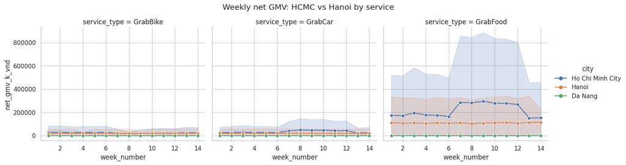

```python
g = sns.relplot(
    data=focus_week_service,
    kind="line",
    x="week_number", y="net_gmv_k_vnd",
    hue="city", col="service_type",
    marker="o", height=4, aspect=1.2
)
g.fig.suptitle("Weekly net GMV: HCMC vs Hanoi by service", y=1.05)
plt.show()
```

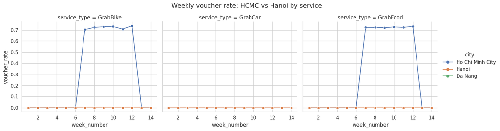

```python
g = sns.relplot(
    data=focus_week_service,
    kind="line",
    x="week_number", y="voucher_rate",
    hue="city", col="service_type",
    marker="o", height=4, aspect=1.2
)
g.fig.suptitle("Weekly voucher rate: HCMC vs Hanoi by service", y=1.05)
plt.show()
```

- Voucher exposure was cleanly limited to HCMC during weeks 7–12 and only for GrabBike and GrabFood, confirming the pilot was implemented as designed, but the uneven GMV response shows the combo did not work equally across the two targeted services.

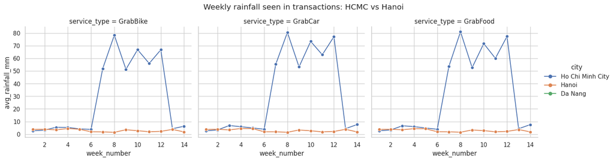

```python
g = sns.relplot(
    data=focus_week_service,
    kind="line",
    x="week_number", y="avg_rainfall_mm",
    hue="city", col="service_type",
    marker="o", height=4, aspect=1.2
)
g.fig.suptitle("Weekly rainfall seen in transactions: HCMC vs Hanoi", y=1.05)
plt.show()
```

- Rainfall in HCMC spiked sharply during the same promo weeks while Hanoi stayed stable, meaning part of the HCMC uplift may have been driven by weather—especially for GrabFood—rather than by the voucher alone.

## KPI Decomposition

### Growth Driver Breakdown

```python
decomp = (
    df_transactions.groupby(["period", "city", "service_type"], observed=False)
    .agg(
        n_transactions=("transaction_id", "count"),
        active_users=("user_id", "nunique"),
        net_gmv_k_vnd=("net_gmv_k_vnd", "sum")
    )
    .reset_index()
)

decomp["txns_per_user"] = decomp["n_transactions"] / decomp["active_users"]
decomp["net_gmv_per_txn"] = decomp["net_gmv_k_vnd"] / decomp["n_transactions"]

decomp.head()
```

|  | period | city | service_type | n_transactions | active_users | net_gmv_k_vnd | txns_per_user | net_gmv_per_txn |
| --- | --- | --- | --- | --- | --- | --- | --- | --- |
| 0 | Pre-Promo | Ho Chi Minh City | GrabBike | 13218 | 5388 | 489,382.00 | 2.45 | 37.02 |
| 1 | Pre-Promo | Ho Chi Minh City | GrabCar | 3661 | 2735 | 476,365.91 | 1.34 | 130.12 |
| 2 | Pre-Promo | Ho Chi Minh City | GrabFood | 19270 | 5762 | 3,174,486.03 | 3.34 | 164.74 |
| 3 | Pre-Promo | Hanoi | GrabBike | 9097 | 3598 | 337,036.71 | 2.53 | 37.05 |
| 4 | Pre-Promo | Hanoi | GrabCar | 2680 | 1963 | 347,691.18 | 1.37 | 129.74 |

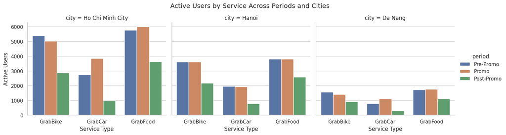

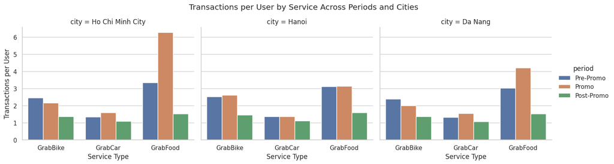

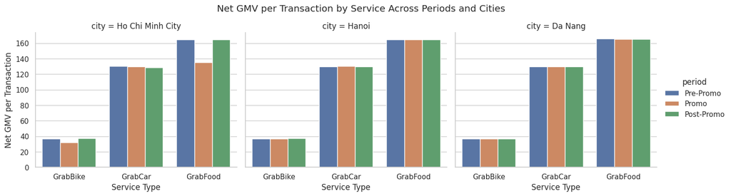

```python
title_map = {
    "active_users": "Active Users by Service Across Periods and Cities",
    "txns_per_user": "Transactions per User by Service Across Periods and Cities",
    "net_gmv_per_txn": "Net GMV per Transaction by Service Across Periods and Cities"
}

y_label_map = {
    "active_users": "Active Users",
    "txns_per_user": "Transactions per User",
    "net_gmv_per_txn": "Net GMV per Transaction"
}

for metric in ["active_users", "txns_per_user", "net_gmv_per_txn"]:
    g = sns.catplot(
        data=decomp,
        kind="bar",
        x="service_type",
        y=metric,
        hue="period",
        col="city",
        height=4,
        aspect=1.2
    )
    g.set_axis_labels("Service Type", y_label_map[metric])
    g.fig.suptitle(title_map[metric], y=1.05)
    plt.show()
```

- **Active Users by Service** The promo period did not produce a broad-based expansion in active users across services. In HCMC, the most visible increase came from GrabCar, while GrabFood user growth was only modest and GrabBike declined, suggesting that topline uplift was not primarily driven by a large increase in user reach.
- **Transactions per User** The clearest behavioral shift in HCMC came from GrabFood, where transactions per user rose sharply during the promo period. This indicates that the campaign was more effective at increasing usage frequency among existing users than at driving broad-based service adoption.
- **Net GMV per Transaction** In HCMC, net GMV per transaction fell during the promo period for the voucher-linked services, especially GrabFood, while remaining broadly stable in Hanoi and Da Nang. This suggests that growth was supported by discount-led repeat usage rather than by higher value per order.

=> The **driver breakdown** suggests that **HCMC’s uplift** was led mainly by increased **GrabFood activity**, especially higher **transaction frequency per user**, while **value per transaction softened** during promo. This implies the campaign stimulated **repeat usage** more effectively than **basket expansion**, with limited evidence of a similarly strong effect across **other services**.

## Pivot Summary by City, Service, and Period

```python
pivot_net = pd.pivot_table(
    df_transactions,
    index=["city", "service_type"],
    columns="period",
    values="net_gmv_k_vnd",
    aggfunc="sum"
)

def color_promo_vs_pre(row):
    styles = [""] * len(row)

    pre = row.get("Pre-Promo", None)
    promo = row.get("Promo", None)

    if pd.notna(pre) and pd.notna(promo):
        promo_idx = row.index.get_loc("Promo")
        if promo > pre:
            styles[promo_idx] = "color: green; font-weight: bold;"
        elif promo < pre:
            styles[promo_idx] = "color: red; font-weight: bold;"

    return styles

styled_pivot = (
    pivot_net.style
    .apply(color_promo_vs_pre, axis=1)
    .format("{:,.2f}")
)

display(Markdown("### Net GMV by City, Service, and Period"))
display(styled_pivot)
```

Net GMV by City, Service, and Period

| city | period service_type | Pre-Promo | Promo | Post-Promo |
| --- | --- | --- | --- | --- |
| Ho Chi Minh City | GrabBike | 489,382.00 | 348,725.18 | 145,069.21 |
|  | GrabCar | 476,365.91 | 801,583.42 | 137,767.06 |
|  | GrabFood | 3,174,486.03 | 5,062,807.84 | 915,339.66 |
| Hanoi | GrabBike | 337,036.71 | 348,973.07 | 119,071.33 |
|  | GrabCar | 347,691.18 | 346,254.89 | 113,463.63 |
|  | GrabFood | 1,950,460.48 | 1,961,698.32 | 685,035.88 |
| Da Nang | GrabBike | 139,085.59 | 104,809.33 | 46,386.90 |
|  | GrabCar | 133,815.37 | 225,564.04 | 44,222.08 |
|  | GrabFood | 854,642.52 | 1,227,206.53 | 282,561.06 |

```python
pivot_voucher = pd.pivot_table(
    df_transactions,
    index=["city", "service_type"],
    columns="period",
    values="voucher_applied",
    aggfunc="mean"
)

def bold_positive(val):
    if pd.notna(val) and val > 0:
        return "font-weight: bold; color: green;"
    return ""

styled_voucher = (
    pivot_voucher.style
    .applymap(bold_positive)
    .format("{:.2f}")
)

display(Markdown("### Voucher Rate by City, Service, and Period"))
display(styled_voucher)
```

Voucher Rate by City, Service, and Period

| city | period service_type | Pre-Promo | Promo | Post-Promo |
| --- | --- | --- | --- | --- |
| Ho Chi Minh City | GrabBike | 0.00 | 0.72 | 0.00 |
|  | GrabCar | 0.00 | 0.00 | 0.00 |
|  | GrabFood | 0.00 | 0.73 | 0.00 |
| Hanoi | GrabBike | 0.00 | 0.00 | 0.00 |
|  | GrabCar | 0.00 | 0.00 | 0.00 |
|  | GrabFood | 0.00 | 0.00 | 0.00 |
| Da Nang | GrabBike | 0.00 | 0.00 | 0.00 |
|  | GrabCar | 0.00 | 0.00 | 0.00 |
|  | GrabFood | 0.00 | 0.00 | 0.00 |

```python
pivot_discount = pd.pivot_table(
    df_transactions,
    index=["city", "service_type"],
    columns="period",
    values="discount_rate",
    aggfunc="mean"
)

def bold_green_positive(val):
    if pd.notna(val) and val > 0:
        return "font-weight: bold; color: green;"
    return ""

styled_discount = (
    pivot_discount.style
    .applymap(bold_green_positive)
    .format("{:.2f}")
)

display(Markdown("### Discount Rate by City, Service, and Period"))
display(styled_discount)
```

Discount Rate by City, Service, and Period

| city | period service_type | Pre-Promo | Promo | Post-Promo |
| --- | --- | --- | --- | --- |
| Ho Chi Minh City | GrabBike | 0.00 | 0.13 | 0.00 |
|  | GrabCar | 0.00 | 0.00 | 0.00 |
|  | GrabFood | 0.00 | 0.18 | 0.00 |
| Hanoi | GrabBike | 0.00 | 0.00 | 0.00 |
|  | GrabCar | 0.00 | 0.00 | 0.00 |
|  | GrabFood | 0.00 | 0.00 | 0.00 |
| Da Nang | GrabBike | 0.00 | 0.00 | 0.00 |
|  | GrabCar | 0.00 | 0.00 | 0.00 |
|  | GrabFood | 0.00 | 0.00 | 0.00 |

## Correlation Heatmap of Transaction Metrics

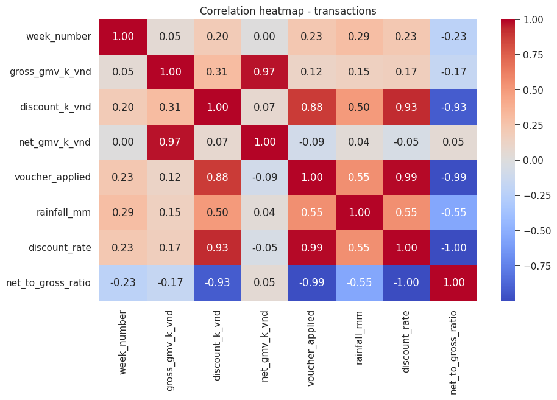

```python
num_cols = [
    "week_number", "gross_gmv_k_vnd", "discount_k_vnd", "net_gmv_k_vnd",
    "voucher_applied", "rainfall_mm", "discount_rate", "net_to_gross_ratio"
]

corr = df_transactions[num_cols].corr(numeric_only=True)

plt.figure(figsize=(10,6))
sns.heatmap(corr, annot=True, fmt=".2f", cmap="coolwarm", center=0)
plt.title("Correlation heatmap - transactions")
plt.show()
```

=> The **heatmap** shows that **voucher exposure, discount intensity, and rainfall** all move together during the pilot period. Specifically, **rainfall** is moderately correlated with both **voucher application** and **discount rate** (**0.55**), which means the **HCMC uplift** cannot be cleanly attributed to the **voucher alone**. At the same time, **voucher usage** is not positively associated with higher **net GMV per transaction** (**-0.09**), suggesting the uplift is more likely **volume- or frequency-driven** than **value-driven**.

## Top Daily GMV Days by City

```python
# Top days by GMV
top_days = (
    df_transactions.groupby(["date", "city"], observed=False)
    .agg(
        net_gmv_k_vnd=("net_gmv_k_vnd", "sum"),
        n_transactions=("transaction_id", "count"),
        active_users=("user_id", "nunique"),
        avg_rainfall_mm=("rainfall_mm", "mean")
    )
    .reset_index()
)

# Map each date to its corresponding campaign period from the original transaction table
period_map = (
    df_transactions[["date", "period"]]
    .drop_duplicates()
)

top_days = top_days.merge(period_map, on="date", how="left")

# Reorder columns and place Period at the end
top_days = top_days[
    ["date", "city", "net_gmv_k_vnd", "n_transactions", "active_users", "avg_rainfall_mm", "period"]
].sort_values("net_gmv_k_vnd", ascending=False)

# Apply background color based on campaign period
def color_period(val):
    if val == "Pre-Promo":
        return "background-color: #cfe2f3;"   # blue-gray
    elif val == "Promo":
        return "background-color: #93c47d;"   # green
    elif val == "Post-Promo":
        return "background-color: #f6b26b;"   # orange
    return ""

styled_top_days = (
    top_days.head(20).style
    .applymap(color_period, subset=["period"])
    .format({
        "net_gmv_k_vnd": "{:,.2f}",
        "n_transactions": "{:,}",
        "active_users": "{:,}",
        "avg_rainfall_mm": "{:,.2f}"
    })
)

display(Markdown("### Top Daily GMV Days by City"))
display(styled_top_days)
```

Top Daily GMV Days by City

|  | date | city | net_gmv_k_vnd | n_transactions | active_users | avg_rainfall_mm | period |
| --- | --- | --- | --- | --- | --- | --- | --- |
| 246 | 2024-03-23 00:00:00 | Ho Chi Minh City | 182,333.99 | 1,552 | 1,380 | 159.20 | Promo |
| 186 | 2024-03-03 00:00:00 | Ho Chi Minh City | 177,936.46 | 1,524 | 1,353 | 66.80 | Promo |
| 183 | 2024-03-02 00:00:00 | Ho Chi Minh City | 177,763.96 | 1,518 | 1,349 | 89.60 | Promo |
| 144 | 2024-02-18 00:00:00 | Ho Chi Minh City | 175,014.07 | 1,476 | 1,317 | 49.60 | Promo |
| 207 | 2024-03-10 00:00:00 | Ho Chi Minh City | 171,399.71 | 1,485 | 1,301 | 75.80 | Promo |
| 129 | 2024-02-13 00:00:00 | Ho Chi Minh City | 171,036.53 | 1,440 | 1,291 | 60.80 | Promo |
| 165 | 2024-02-25 00:00:00 | Ho Chi Minh City | 163,344.52 | 1,376 | 1,225 | 98.10 | Promo |
| 225 | 2024-03-16 00:00:00 | Ho Chi Minh City | 162,481.37 | 1,395 | 1,243 | 67.80 | Promo |
| 162 | 2024-02-24 00:00:00 | Ho Chi Minh City | 159,142.26 | 1,387 | 1,232 | 36.40 | Promo |
| 177 | 2024-02-29 00:00:00 | Ho Chi Minh City | 159,012.49 | 1,355 | 1,218 | 46.60 | Promo |
| 210 | 2024-03-11 00:00:00 | Ho Chi Minh City | 155,811.33 | 1,364 | 1,235 | 53.00 | Promo |
| 189 | 2024-03-04 00:00:00 | Ho Chi Minh City | 155,037.67 | 1,349 | 1,207 | 64.90 | Promo |
| 171 | 2024-02-27 00:00:00 | Ho Chi Minh City | 153,189.79 | 1,325 | 1,181 | 38.40 | Promo |
| 201 | 2024-03-08 00:00:00 | Ho Chi Minh City | 152,384.85 | 1,319 | 1,187 | 56.00 | Promo |
| 132 | 2024-02-14 00:00:00 | Ho Chi Minh City | 152,314.85 | 1,321 | 1,180 | 55.90 | Promo |
| 156 | 2024-02-22 00:00:00 | Ho Chi Minh City | 152,138.09 | 1,313 | 1,176 | 69.70 | Promo |
| 195 | 2024-03-06 00:00:00 | Ho Chi Minh City | 151,920.38 | 1,308 | 1,174 | 66.40 | Promo |
| 240 | 2024-03-21 00:00:00 | Ho Chi Minh City | 151,420.77 | 1,315 | 1,160 | 45.90 | Promo |
| 180 | 2024-03-01 00:00:00 | Ho Chi Minh City | 150,650.18 | 1,304 | 1,184 | 49.00 | Promo |
| 231 | 2024-03-18 00:00:00 | Ho Chi Minh City | 149,790.86 | 1,309 | 1,189 | 111.80 | Promo |

=> **Daily GMV spikes** are dominated by **HCMC during promo**, with several **peak days** occurring alongside **unusually high rainfall**. This suggests that the **strongest performance days** were not driven purely by the **campaign**, but were also supported by **external demand factors**, especially **weather**.

## Executive Summary of Key Metrics by City and Period

```python
executive_summary = (
    df_transactions.groupby(["city", "period"], observed=False)
    .agg(
        transactions=("transaction_id", "count"),
        active_users=("user_id", "nunique"),
        gross_gmv_k_vnd=("gross_gmv_k_vnd", "sum"),
        discount_k_vnd=("discount_k_vnd", "sum"),
        net_gmv_k_vnd=("net_gmv_k_vnd", "sum"),
        voucher_txns=("voucher_applied", "sum"),
        avg_rainfall_mm=("rainfall_mm", "mean")
    )
    .reset_index()
)

executive_summary["txns_per_user"] = executive_summary["transactions"] / executive_summary["active_users"]
executive_summary["net_gmv_per_txn"] = executive_summary["net_gmv_k_vnd"] / executive_summary["transactions"]
executive_summary["voucher_rate"] = executive_summary["voucher_txns"] / executive_summary["transactions"]
executive_summary["discount_rate"] = executive_summary["discount_k_vnd"] / executive_summary["gross_gmv_k_vnd"]

display(executive_summary)
```

|  | city | period | transactions | active_users | gross_gmv_k_vnd | discount_k_vnd | net_gmv_k_vnd | voucher_txns | avg_rainfall_mm | txns_per_user | net_gmv_per_txn | voucher_rate | discount_rate |
| --- | --- | --- | --- | --- | --- | --- | --- | --- | --- | --- | --- | --- | --- |
| 0 | Ho Chi Minh City | Pre-Promo | 36149 | 5986 | 4,140,233.94 | 0.00 | 4,140,233.94 | 0 | 4.42 | 6.04 | 114.53 | 0.00 | 0.00 |
| 1 | Ho Chi Minh City | Promo | 54502 | 5999 | 7,386,069.08 | 1,172,951.28 | 6,213,116.44 | 35015 | 65.23 | 9.09 | 114.00 | 0.64 | 0.16 |
| 2 | Ho Chi Minh City | Post-Promo | 10539 | 4940 | 1,198,175.93 | 0.00 | 1,198,175.93 | 0 | 5.71 | 2.13 | 113.69 | 0.00 | 0.00 |
| 3 | Hanoi | Pre-Promo | 23610 | 3989 | 2,635,188.37 | 0.00 | 2,635,188.37 | 0 | 3.59 | 5.92 | 111.61 | 0.00 | 0.00 |
| 4 | Hanoi | Promo | 24008 | 3997 | 2,656,926.28 | 0.00 | 2,656,926.28 | 0 | 2.27 | 6.01 | 110.67 | 0.00 | 0.00 |
| 5 | Hanoi | Post-Promo | 8242 | 3503 | 917,570.84 | 0.00 | 917,570.84 | 0 | 2.76 | 2.35 | 111.33 | 0.00 | 0.00 |
| 6 | Da Nang | Pre-Promo | 9951 | 1790 | 1,127,543.48 | 0.00 | 1,127,543.48 | 0 | 5.77 | 5.56 | 113.31 | 0.00 | 0.00 |
| 7 | Da Nang | Promo | 12006 | 1798 | 1,557,579.90 | 0.00 | 1,557,579.90 | 0 | 50.51 | 6.68 | 129.73 | 0.00 | 0.00 |
| 8 | Da Nang | Post-Promo | 3306 | 1521 | 373,170.04 | 0.00 | 373,170.04 | 0 | 5.12 | 2.17 | 112.88 | 0.00 | 0.00 |

# Business Analysis

## Weekly City-Level KPI Analysis

```python
conn = sqlite3.connect(db_path)

query_weekly_city_performance = """
SELECT
    week_number,
    period,
    city,
    COUNT(*) AS n_transactions,
    COUNT(DISTINCT user_id) AS active_users,
    SUM(gross_gmv_k_vnd) AS gross_gmv_k_vnd,
    SUM(discount_k_vnd) AS discount_k_vnd,
    SUM(net_gmv_k_vnd) AS net_gmv_k_vnd,
    SUM(voucher_applied) AS voucher_txns,
    AVG(rainfall_mm) AS avg_rainfall_mm
FROM transactions
GROUP BY
    week_number,
    period,
    city
ORDER BY
    week_number,
    city;
"""

weekly_city_kpi = pd.read_sql_query(query_weekly_city_performance, conn)

weekly_city_kpi["txns_per_user"] = weekly_city_kpi["n_transactions"] / weekly_city_kpi["active_users"]
weekly_city_kpi["net_gmv_per_txn"] = weekly_city_kpi["net_gmv_k_vnd"] / weekly_city_kpi["n_transactions"]
weekly_city_kpi["voucher_rate"] = weekly_city_kpi["voucher_txns"] / weekly_city_kpi["n_transactions"]
weekly_city_kpi["discount_rate"] = weekly_city_kpi["discount_k_vnd"] / weekly_city_kpi["gross_gmv_k_vnd"]
```

```python
print(weekly_city_kpi.shape)
```

```
(42, 14)
```

```python
weekly_city_kpi.head()
```

|  | week_number | period | city | n_transactions | active_users | gross_gmv_k_vnd | discount_k_vnd | net_gmv_k_vnd | voucher_txns | avg_rainfall_mm | txns_per_user | net_gmv_per_txn | voucher_rate | discount_rate |
| --- | --- | --- | --- | --- | --- | --- | --- | --- | --- | --- | --- | --- | --- | --- |
| 0 | 1 | Pre-Promo | Da Nang | 1678 | 1092 | 193,488.08 | 0.00 | 193,488.08 | 0 | 8.90 | 1.54 | 115.31 | 0.00 | 0.00 |
| 1 | 1 | Pre-Promo | Hanoi | 4016 | 2485 | 448,404.56 | 0.00 | 448,404.56 | 0 | 3.71 | 1.62 | 111.65 | 0.00 | 0.00 |
| 2 | 1 | Pre-Promo | Ho Chi Minh City | 6008 | 3781 | 679,830.94 | 0.00 | 679,830.94 | 0 | 2.67 | 1.59 | 113.15 | 0.00 | 0.00 |
| 3 | 2 | Pre-Promo | Da Nang | 1647 | 1104 | 184,522.64 | 0.00 | 184,522.64 | 0 | 4.35 | 1.49 | 112.04 | 0.00 | 0.00 |
| 4 | 2 | Pre-Promo | Hanoi | 3883 | 2492 | 438,078.51 | 0.00 | 438,078.51 | 0 | 3.89 | 1.56 | 112.82 | 0.00 | 0.00 |

```python
weekly_city_kpi.groupby(["period", "city"], observed=False).size().reset_index(name="n_rows")
```

|  | period | city | n_rows |
| --- | --- | --- | --- |
| 0 | Post-Promo | Da Nang | 2 |
| 1 | Post-Promo | Hanoi | 2 |
| 2 | Post-Promo | Ho Chi Minh City | 2 |
| 3 | Pre-Promo | Da Nang | 6 |
| 4 | Pre-Promo | Hanoi | 6 |
| 5 | Pre-Promo | Ho Chi Minh City | 6 |
| 6 | Promo | Da Nang | 6 |
| 7 | Promo | Hanoi | 6 |
| 8 | Promo | Ho Chi Minh City | 6 |

=> At the **city level**, **HCMC** shows the most visible **KPI uplift** during the **promo period**, but the improvement should not be read as **pure promo impact** without accounting for **external demand drivers** and **underlying city differences**.

## Weekly City-Service KPI Analysis

```python
query_weekly_city_service_kpi = """
SELECT
    week_number,
    period,
    city,
    service_type,
    COUNT(*) AS n_transactions,
    COUNT(DISTINCT user_id) AS active_users,
    SUM(gross_gmv_k_vnd) AS gross_gmv_k_vnd,
    SUM(discount_k_vnd) AS discount_k_vnd,
    SUM(net_gmv_k_vnd) AS net_gmv_k_vnd,
    SUM(voucher_applied) AS voucher_txns,
    AVG(rainfall_mm) AS avg_rainfall_mm
FROM transactions
GROUP BY 1,2,3,4
ORDER BY 1,3,4
"""

weekly_city_service_kpi = pd.read_sql_query(query_weekly_city_service_kpi, conn)

weekly_city_service_kpi["txns_per_user"] = (
    weekly_city_service_kpi["n_transactions"] / weekly_city_service_kpi["active_users"]
)
weekly_city_service_kpi["net_gmv_per_txn"] = (
    weekly_city_service_kpi["net_gmv_k_vnd"] / weekly_city_service_kpi["n_transactions"]
)
weekly_city_service_kpi["voucher_rate"] = (
    weekly_city_service_kpi["voucher_txns"] / weekly_city_service_kpi["n_transactions"]
)
weekly_city_service_kpi["discount_rate"] = (
    weekly_city_service_kpi["discount_k_vnd"] / weekly_city_service_kpi["gross_gmv_k_vnd"]
)
```

```python
weekly_city_service_kpi.shape
```

```
(126, 15)
```

```python
weekly_city_service_kpi.head()
```

|  | week_number | period | city | service_type | n_transactions | active_users | gross_gmv_k_vnd | discount_k_vnd | net_gmv_k_vnd | voucher_txns | avg_rainfall_mm | txns_per_user | net_gmv_per_txn | voucher_rate | discount_rate |
| --- | --- | --- | --- | --- | --- | --- | --- | --- | --- | --- | --- | --- | --- | --- | --- |
| 0 | 1 | Pre-Promo | Da Nang | GrabBike | 606 | 524 | 22,294.91 | 0.00 | 22,294.91 | 0 | 7.83 | 1.16 | 36.79 | 0.00 | 0.00 |
| 1 | 1 | Pre-Promo | Da Nang | GrabCar | 182 | 173 | 23,545.81 | 0.00 | 23,545.81 | 0 | 9.54 | 1.05 | 129.37 | 0.00 | 0.00 |
| 2 | 1 | Pre-Promo | Da Nang | GrabFood | 890 | 691 | 147,647.36 | 0.00 | 147,647.36 | 0 | 9.50 | 1.29 | 165.90 | 0.00 | 0.00 |
| 3 | 1 | Pre-Promo | Hanoi | GrabBike | 1545 | 1275 | 57,302.26 | 0.00 | 57,302.26 | 0 | 3.71 | 1.21 | 37.09 | 0.00 | 0.00 |
| 4 | 1 | Pre-Promo | Hanoi | GrabCar | 428 | 400 | 55,292.88 | 0.00 | 55,292.88 | 0 | 3.70 | 1.07 | 129.19 | 0.00 | 0.00 |

=> The **weekly service-level view** shows that **HCMC’s uplift** was uneven across **services**, with performance concentrated more strongly in **GrabFood** than in **mobility**, indicating a **service-mix shift** rather than **broad-based marketplace acceleration**.

## Voucher Exposure Check

```python
query_voucher = """
SELECT
    period,
    city,
    service_type,
    SUM(voucher_applied) AS voucher_txns,
    COUNT(*) AS total_txns,
    AVG(voucher_applied) AS voucher_rate
FROM transactions
GROUP BY 1,2,3
ORDER BY 1,2,3
"""
voucher_check = pd.read_sql_query(query_voucher, conn)
```

```python
voucher_check.head()
```

|  | period | city | service_type | voucher_txns | total_txns | voucher_rate |
| --- | --- | --- | --- | --- | --- | --- |
| 0 | Post-Promo | Da Nang | GrabBike | 0 | 1252 | 0.00 |
| 1 | Post-Promo | Da Nang | GrabCar | 0 | 341 | 0.00 |
| 2 | Post-Promo | Da Nang | GrabFood | 0 | 1713 | 0.00 |
| 3 | Post-Promo | Hanoi | GrabBike | 0 | 3207 | 0.00 |
| 4 | Post-Promo | Hanoi | GrabCar | 0 | 873 | 0.00 |

=> **Voucher usage** was tightly concentrated in **HCMC** during the **promo window**, confirming that the **pilot** was implemented as intended and that observed changes in **HCMC** can reasonably be evaluated against **non-exposed markets**.

## Average Weekly KPI Summary by City and Period

```python
period_city_summary = (
    weekly_city_kpi
    .groupby(["period", "city"], observed=False)
    .agg(
        avg_weekly_transactions=("n_transactions", "mean"),
        avg_weekly_active_users=("active_users", "mean"),
        avg_weekly_gross_gmv=("gross_gmv_k_vnd", "mean"),
        avg_weekly_discount=("discount_k_vnd", "mean"),
        avg_weekly_net_gmv=("net_gmv_k_vnd", "mean"),
        avg_weekly_voucher_rate=("voucher_rate", "mean"),
        avg_weekly_discount_rate=("discount_rate", "mean"),
        avg_weekly_txns_per_user=("txns_per_user", "mean"),
        avg_weekly_net_gmv_per_txn=("net_gmv_per_txn", "mean"),
        avg_weekly_rainfall=("avg_rainfall_mm", "mean")
    )
    .reset_index()
)

display(period_city_summary)
```

|  | period | city | avg_weekly_transactions | avg_weekly_active_users | avg_weekly_gross_gmv | avg_weekly_discount | avg_weekly_net_gmv | avg_weekly_voucher_rate | avg_weekly_discount_rate | avg_weekly_txns_per_user | avg_weekly_net_gmv_per_txn | avg_weekly_rainfall |
| --- | --- | --- | --- | --- | --- | --- | --- | --- | --- | --- | --- | --- |
| 0 | Post-Promo | Da Nang | 1,653.00 | 1,085.50 | 186,585.02 | 0.00 | 186,585.02 | 0.00 | 0.00 | 1.52 | 112.88 | 5.12 |
| 1 | Post-Promo | Hanoi | 4,121.00 | 2,582.00 | 458,785.42 | 0.00 | 458,785.42 | 0.00 | 0.00 | 1.60 | 111.33 | 2.75 |
| 2 | Post-Promo | Ho Chi Minh City | 5,269.50 | 3,520.00 | 599,087.96 | 0.00 | 599,087.96 | 0.00 | 0.00 | 1.50 | 113.69 | 5.71 |
| 3 | Pre-Promo | Da Nang | 1,658.50 | 1,086.67 | 187,923.91 | 0.00 | 187,923.91 | 0.00 | 0.00 | 1.53 | 113.31 | 5.76 |
| 4 | Pre-Promo | Hanoi | 3,935.00 | 2,503.67 | 439,198.06 | 0.00 | 439,198.06 | 0.00 | 0.00 | 1.57 | 111.62 | 3.59 |
| 5 | Pre-Promo | Ho Chi Minh City | 6,024.83 | 3,816.83 | 690,038.99 | 0.00 | 690,038.99 | 0.00 | 0.00 | 1.58 | 114.48 | 4.40 |
| 6 | Promo | Da Nang | 2,001.00 | 1,214.50 | 259,596.65 | 0.00 | 259,596.65 | 0.00 | 0.00 | 1.65 | 129.69 | 50.30 |
| 7 | Promo | Hanoi | 4,001.33 | 2,523.83 | 442,821.05 | 0.00 | 442,821.05 | 0.00 | 0.00 | 1.59 | 110.66 | 2.26 |
| 8 | Promo | Ho Chi Minh City | 9,083.67 | 4,679.50 | 1,231,011.51 | 195,491.88 | 1,035,519.41 | 0.64 | 0.16 | 1.94 | 113.99 | 65.36 |

=> On an **average weekly basis**, **HCMC** outperformed the **other cities** during **promo**, but this summary remains **descriptive** and does not by itself separate **true incremental uplift** from **normal market variation** or **external influences**.

## Average Weekly KPI Summary by City, Service, and Period

```python
period_city_service_summary = (
    weekly_city_service_kpi
    .groupby(["period", "city", "service_type"], observed=False)
    .agg(
        avg_weekly_transactions=("n_transactions", "mean"),
        avg_weekly_active_users=("active_users", "mean"),
        avg_weekly_gross_gmv=("gross_gmv_k_vnd", "mean"),
        avg_weekly_discount=("discount_k_vnd", "mean"),
        avg_weekly_net_gmv=("net_gmv_k_vnd", "mean"),
        avg_weekly_voucher_rate=("voucher_rate", "mean"),
        avg_weekly_discount_rate=("discount_rate", "mean"),
        avg_weekly_txns_per_user=("txns_per_user", "mean"),
        avg_weekly_net_gmv_per_txn=("net_gmv_per_txn", "mean"),
        avg_weekly_rainfall=("avg_rainfall_mm", "mean")
    )
    .reset_index()
)

display(period_city_service_summary)
```

|  | period | city | service_type | avg_weekly_transactions | avg_weekly_active_users | avg_weekly_gross_gmv | avg_weekly_discount | avg_weekly_net_gmv | avg_weekly_voucher_rate | avg_weekly_discount_rate | avg_weekly_txns_per_user | avg_weekly_net_gmv_per_txn | avg_weekly_rainfall |
| --- | --- | --- | --- | --- | --- | --- | --- | --- | --- | --- | --- | --- | --- |
| 0 | Post-Promo | Da Nang | GrabBike | 626.00 | 533.50 | 23,193.45 | 0.00 | 23,193.45 | 0.00 | 0.00 | 1.17 | 37.04 | 4.78 |
| 1 | Post-Promo | Da Nang | GrabCar | 170.50 | 163.50 | 22,111.04 | 0.00 | 22,111.04 | 0.00 | 0.00 | 1.04 | 129.70 | 5.28 |
| 2 | Post-Promo | Da Nang | GrabFood | 856.50 | 687.50 | 141,280.53 | 0.00 | 141,280.53 | 0.00 | 0.00 | 1.25 | 164.98 | 5.32 |
| 3 | Post-Promo | Hanoi | GrabBike | 1,603.50 | 1,316.00 | 59,535.67 | 0.00 | 59,535.67 | 0.00 | 0.00 | 1.22 | 37.13 | 2.77 |
| 4 | Post-Promo | Hanoi | GrabCar | 436.50 | 411.50 | 56,731.81 | 0.00 | 56,731.81 | 0.00 | 0.00 | 1.06 | 129.97 | 2.80 |
| 5 | Post-Promo | Hanoi | GrabFood | 2,081.00 | 1,627.50 | 342,517.94 | 0.00 | 342,517.94 | 0.00 | 0.00 | 1.28 | 164.60 | 2.73 |
| 6 | Post-Promo | Ho Chi Minh City | GrabBike | 1,955.00 | 1,662.50 | 72,534.60 | 0.00 | 72,534.60 | 0.00 | 0.00 | 1.18 | 37.10 | 5.29 |
| 7 | Post-Promo | Ho Chi Minh City | GrabCar | 535.00 | 513.00 | 68,883.53 | 0.00 | 68,883.53 | 0.00 | 0.00 | 1.04 | 128.76 | 6.00 |
| 8 | Post-Promo | Ho Chi Minh City | GrabFood | 2,779.50 | 2,226.00 | 457,669.83 | 0.00 | 457,669.83 | 0.00 | 0.00 | 1.25 | 164.66 | 5.93 |
| 9 | Pre-Promo | Da Nang | GrabBike | 626.00 | 529.17 | 23,180.93 | 0.00 | 23,180.93 | 0.00 | 0.00 | 1.18 | 37.03 | 5.51 |
| 10 | Pre-Promo | Da Nang | GrabCar | 172.17 | 166.17 | 22,302.56 | 0.00 | 22,302.56 | 0.00 | 0.00 | 1.04 | 129.53 | 5.96 |
| 11 | Pre-Promo | Da Nang | GrabFood | 860.33 | 682.00 | 142,440.42 | 0.00 | 142,440.42 | 0.00 | 0.00 | 1.26 | 165.57 | 5.90 |
| 12 | Pre-Promo | Hanoi | GrabBike | 1,516.17 | 1,256.67 | 56,172.78 | 0.00 | 56,172.78 | 0.00 | 0.00 | 1.21 | 37.05 | 3.55 |
| 13 | Pre-Promo | Hanoi | GrabCar | 446.67 | 424.83 | 57,948.53 | 0.00 | 57,948.53 | 0.00 | 0.00 | 1.05 | 129.74 | 3.63 |
| 14 | Pre-Promo | Hanoi | GrabFood | 1,972.17 | 1,555.67 | 325,076.75 | 0.00 | 325,076.75 | 0.00 | 0.00 | 1.27 | 164.84 | 3.61 |
| 15 | Pre-Promo | Ho Chi Minh City | GrabBike | 2,203.00 | 1,860.33 | 81,563.67 | 0.00 | 81,563.67 | 0.00 | 0.00 | 1.18 | 37.03 | 4.10 |
| 16 | Pre-Promo | Ho Chi Minh City | GrabCar | 610.17 | 582.17 | 79,394.32 | 0.00 | 79,394.32 | 0.00 | 0.00 | 1.05 | 130.10 | 4.59 |
| 17 | Pre-Promo | Ho Chi Minh City | GrabFood | 3,211.67 | 2,488.17 | 529,081.01 | 0.00 | 529,081.01 | 0.00 | 0.00 | 1.29 | 164.75 | 4.57 |
| 18 | Promo | Da Nang | GrabBike | 473.33 | 412.00 | 17,468.22 | 0.00 | 17,468.22 | 0.00 | 0.00 | 1.15 | 36.90 | 47.31 |
| 19 | Promo | Da Nang | GrabCar | 289.00 | 267.17 | 37,594.01 | 0.00 | 37,594.01 | 0.00 | 0.00 | 1.08 | 130.05 | 51.92 |
| 20 | Promo | Da Nang | GrabFood | 1,238.67 | 897.67 | 204,534.42 | 0.00 | 204,534.42 | 0.00 | 0.00 | 1.38 | 165.13 | 51.08 |
| 21 | Promo | Hanoi | GrabBike | 1,572.17 | 1,292.17 | 58,162.18 | 0.00 | 58,162.18 | 0.00 | 0.00 | 1.22 | 36.99 | 2.27 |
| 22 | Promo | Hanoi | GrabCar | 442.00 | 421.83 | 57,709.15 | 0.00 | 57,709.15 | 0.00 | 0.00 | 1.05 | 130.56 | 2.22 |
| 23 | Promo | Hanoi | GrabFood | 1,987.17 | 1,570.67 | 326,949.72 | 0.00 | 326,949.72 | 0.00 | 0.00 | 1.27 | 164.52 | 2.27 |
| 24 | Promo | Ho Chi Minh City | GrabBike | 1,807.17 | 1,545.83 | 66,801.02 | 8,680.16 | 58,120.86 | 0.72 | 0.13 | 1.17 | 32.16 | 61.91 |
| 25 | Promo | Ho Chi Minh City | GrabCar | 1,028.67 | 941.00 | 133,597.24 | 0.00 | 133,597.24 | 0.00 | 0.00 | 1.09 | 129.87 | 67.14 |
| 26 | Promo | Ho Chi Minh City | GrabFood | 6,247.83 | 3,891.50 | 1,030,613.26 | 186,811.72 | 843,801.31 | 0.73 | 0.18 | 1.61 | 135.05 | 66.11 |

=> The **more granular weekly summary** shows that the **promo effect in HCMC** was highly concentrated by **service**, with **GrabFood** contributing the **majority of the uplift** and **other services** showing a more limited response.

## Average Weekly KPI Summary by City and Period

```python
period_city_summary = (
    weekly_city_kpi
    .groupby(["period", "city"], observed=False)
    .agg(
        avg_weekly_transactions=("n_transactions", "mean"),
        avg_weekly_active_users=("active_users", "mean"),
        avg_weekly_gross_gmv=("gross_gmv_k_vnd", "mean"),
        avg_weekly_discount=("discount_k_vnd", "mean"),
        avg_weekly_net_gmv=("net_gmv_k_vnd", "mean"),
        avg_weekly_voucher_rate=("voucher_rate", "mean"),
        avg_weekly_discount_rate=("discount_rate", "mean"),
        avg_weekly_txns_per_user=("txns_per_user", "mean"),
        avg_weekly_net_gmv_per_txn=("net_gmv_per_txn", "mean"),
        avg_weekly_rainfall=("avg_rainfall_mm", "mean")
    )
    .reset_index()
)
```

```python
period_city_summary.head()
```

|  | period | city | avg_weekly_transactions | avg_weekly_active_users | avg_weekly_gross_gmv | avg_weekly_discount | avg_weekly_net_gmv | avg_weekly_voucher_rate | avg_weekly_discount_rate | avg_weekly_txns_per_user | avg_weekly_net_gmv_per_txn | avg_weekly_rainfall |
| --- | --- | --- | --- | --- | --- | --- | --- | --- | --- | --- | --- | --- |
| 0 | Post-Promo | Da Nang | 1,653.00 | 1,085.50 | 186,585.02 | 0.00 | 186,585.02 | 0.00 | 0.00 | 1.52 | 112.88 | 5.12 |
| 1 | Post-Promo | Hanoi | 4,121.00 | 2,582.00 | 458,785.42 | 0.00 | 458,785.42 | 0.00 | 0.00 | 1.60 | 111.33 | 2.75 |
| 2 | Post-Promo | Ho Chi Minh City | 5,269.50 | 3,520.00 | 599,087.96 | 0.00 | 599,087.96 | 0.00 | 0.00 | 1.50 | 113.69 | 5.71 |
| 3 | Pre-Promo | Da Nang | 1,658.50 | 1,086.67 | 187,923.91 | 0.00 | 187,923.91 | 0.00 | 0.00 | 1.53 | 113.31 | 5.76 |
| 4 | Pre-Promo | Hanoi | 3,935.00 | 2,503.67 | 439,198.06 | 0.00 | 439,198.06 | 0.00 | 0.00 | 1.57 | 111.62 | 3.59 |

=> Comparing **average weekly KPIs** across **periods** highlights a **clear promo-period lift** in **HCMC**, but also shows that **performance weakened after promo ended**, raising questions about the **durability of the observed gains**.

## Weekly Net GMV Trend by City

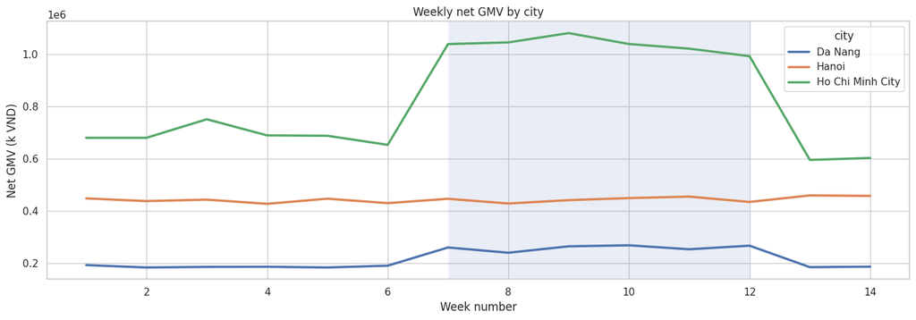

```python
import matplotlib.pyplot as plt
import seaborn as sns

plt.figure(figsize=(14,5))
sns.lineplot(
    data=weekly_city_kpi,
    x="week_number",
    y="net_gmv_k_vnd",
    hue="city",
    linewidth=2.5
)
plt.axvspan(7, 12, alpha=0.12)
plt.title("Weekly net GMV by city")
plt.xlabel("Week number")
plt.ylabel("Net GMV (k VND)")
plt.tight_layout()
plt.show()
```

=> **Weekly net GMV trends** indicate that **HCMC** experienced a **clear step-up** during the **promo period** relative to **Hanoi** and **Da Nang**, but the **timing alone** is not sufficient to attribute the **full uplift** to the **voucher** without further **diagnostic checks**.

## Weekly Net GMV by Service in HCMC

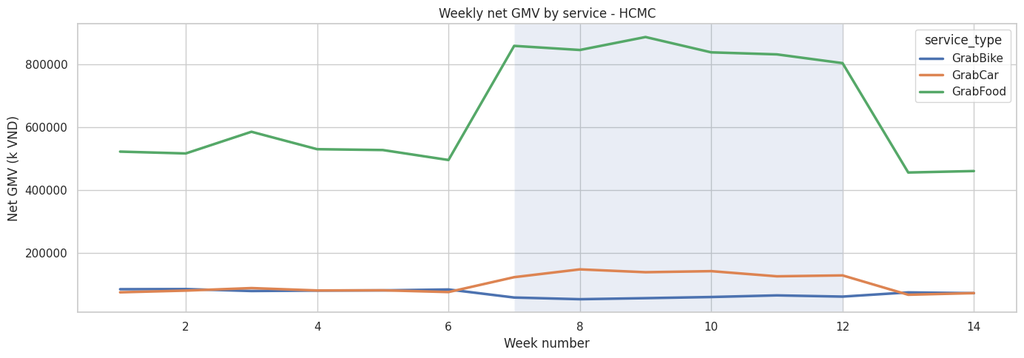

```python
hcmc_service = weekly_city_service_kpi[
    weekly_city_service_kpi["city"] == "Ho Chi Minh City"
].copy()

plt.figure(figsize=(14,5))
sns.lineplot(
    data=hcmc_service,
    x="week_number",
    y="net_gmv_k_vnd",
    hue="service_type",
    linewidth=2.5
)
plt.axvspan(7, 12, alpha=0.12)
plt.title("Weekly net GMV by service - HCMC")
plt.xlabel("Week number")
plt.ylabel("Net GMV (k VND)")
plt.tight_layout()
plt.show()
```

=> Within **HCMC**, the **weekly net GMV pattern** suggests that **GrabFood** was the **dominant contributor** to **promo-period growth**, while **other services** contributed less consistently, weakening the case for a **balanced combo effect**.

## City-Level KPI Change: Pre-Promo vs Promo

```python
metrics_city = [
    "avg_weekly_transactions",
    "avg_weekly_active_users",
    "avg_weekly_gross_gmv",
    "avg_weekly_discount",
    "avg_weekly_net_gmv",
    "avg_weekly_voucher_rate",
    "avg_weekly_discount_rate",
    "avg_weekly_txns_per_user",
    "avg_weekly_net_gmv_per_txn",
    "avg_weekly_rainfall"
]

city_pre = (
    period_city_summary[period_city_summary["period"] == "Pre-Promo"]
    [["city"] + metrics_city]
    .rename(columns={c: f"{c}_pre" for c in metrics_city})
)

city_promo = (
    period_city_summary[period_city_summary["period"] == "Promo"]
    [["city"] + metrics_city]
    .rename(columns={c: f"{c}_promo" for c in metrics_city})
)

city_delta = city_pre.merge(city_promo, on="city", how="inner")

for m in metrics_city:
    city_delta[f"{m}_abs_change"] = city_delta[f"{m}_promo"] - city_delta[f"{m}_pre"]
    city_delta[f"{m}_pct_change"] = np.where(
        city_delta[f"{m}_pre"] != 0,
        city_delta[f"{m}_abs_change"] / city_delta[f"{m}_pre"],
        np.nan
    )

city_delta
```

|  | city | avg_weekly_transactions_pre | avg_weekly_active_users_pre | avg_weekly_gross_gmv_pre | avg_weekly_discount_pre | avg_weekly_net_gmv_pre | avg_weekly_voucher_rate_pre | avg_weekly_discount_rate_pre | avg_weekly_txns_per_user_pre | avg_weekly_net_gmv_per_txn_pre | avg_weekly_rainfall_pre | avg_weekly_transactions_promo | avg_weekly_active_users_promo | avg_weekly_gross_gmv_promo | avg_weekly_discount_promo | avg_weekly_net_gmv_promo | avg_weekly_voucher_rate_promo | avg_weekly_discount_rate_promo | avg_weekly_txns_per_user_promo | avg_weekly_net_gmv_per_txn_promo | avg_weekly_rainfall_promo | avg_weekly_transactions_abs_change | avg_weekly_transactions_pct_change | avg_weekly_active_users_abs_change | avg_weekly_active_users_pct_change | avg_weekly_gross_gmv_abs_change | avg_weekly_gross_gmv_pct_change | avg_weekly_discount_abs_change | avg_weekly_discount_pct_change | … |
| --- | --- | --- | --- | --- | --- | --- | --- | --- | --- | --- | --- | --- | --- | --- | --- | --- | --- | --- | --- | --- | --- | --- | --- | --- | --- | --- | --- | --- | --- | --- |
| 0 | Da Nang | 1,658.50 | 1,086.67 | 187,923.91 | 0.00 | 187,923.91 | 0.00 | 0.00 | 1.53 | 113.31 | 5.76 | 2,001.00 | 1,214.50 | 259,596.65 | 0.00 | 259,596.65 | 0.00 | 0.00 | 1.65 | 129.69 | 50.30 | 342.50 | 0.21 | 127.83 | 0.12 | 71,672.74 | 0.38 | 0.00 | NaN | … |
| 1 | Hanoi | 3,935.00 | 2,503.67 | 439,198.06 | 0.00 | 439,198.06 | 0.00 | 0.00 | 1.57 | 111.62 | 3.59 | 4,001.33 | 2,523.83 | 442,821.05 | 0.00 | 442,821.05 | 0.00 | 0.00 | 1.59 | 110.66 | 2.26 | 66.33 | 0.02 | 20.17 | 0.01 | 3,622.99 | 0.01 | 0.00 | NaN | … |
| 2 | Ho Chi Minh City | 6,024.83 | 3,816.83 | 690,038.99 | 0.00 | 690,038.99 | 0.00 | 0.00 | 1.58 | 114.48 | 4.40 | 9,083.67 | 4,679.50 | 1,231,011.51 | 195,491.88 | 1,035,519.41 | 0.64 | 0.16 | 1.94 | 113.99 | 65.36 | 3,058.83 | 0.51 | 862.67 | 0.23 | 540,972.52 | 0.78 | 195,491.88 | NaN | … |

```python
city_delta_view = city_delta[[
    "city",
    "avg_weekly_net_gmv_pre",
    "avg_weekly_net_gmv_promo",
    "avg_weekly_net_gmv_abs_change",
    "avg_weekly_net_gmv_pct_change",
    "avg_weekly_transactions_pre",
    "avg_weekly_transactions_promo",
    "avg_weekly_transactions_abs_change",
    "avg_weekly_transactions_pct_change",
    "avg_weekly_active_users_pre",
    "avg_weekly_active_users_promo",
    "avg_weekly_active_users_abs_change",
    "avg_weekly_active_users_pct_change",
    "avg_weekly_discount_rate_pre",
    "avg_weekly_discount_rate_promo",
    "avg_weekly_discount_rate_abs_change",
    "avg_weekly_rainfall_pre",
    "avg_weekly_rainfall_promo",
    "avg_weekly_rainfall_abs_change"
]].copy()

display(city_delta_view)
```

|  | city | avg_weekly_net_gmv_pre | avg_weekly_net_gmv_promo | avg_weekly_net_gmv_abs_change | avg_weekly_net_gmv_pct_change | avg_weekly_transactions_pre | avg_weekly_transactions_promo | avg_weekly_transactions_abs_change | avg_weekly_transactions_pct_change | avg_weekly_active_users_pre | avg_weekly_active_users_promo | avg_weekly_active_users_abs_change | avg_weekly_active_users_pct_change | avg_weekly_discount_rate_pre | avg_weekly_discount_rate_promo | avg_weekly_discount_rate_abs_change | avg_weekly_rainfall_pre | avg_weekly_rainfall_promo | avg_weekly_rainfall_abs_change |
| --- | --- | --- | --- | --- | --- | --- | --- | --- | --- | --- | --- | --- | --- | --- | --- | --- | --- | --- | --- |
| 0 | Da Nang | 187,923.91 | 259,596.65 | 71,672.74 | 0.38 | 1,658.50 | 2,001.00 | 342.50 | 0.21 | 1,086.67 | 1,214.50 | 127.83 | 0.12 | 0.00 | 0.00 | 0.00 | 5.76 | 50.30 | 44.54 |
| 1 | Hanoi | 439,198.06 | 442,821.05 | 3,622.99 | 0.01 | 3,935.00 | 4,001.33 | 66.33 | 0.02 | 2,503.67 | 2,523.83 | 20.17 | 0.01 | 0.00 | 0.00 | 0.00 | 3.59 | 2.26 | -1.32 |
| 2 | Ho Chi Minh City | 690,038.99 | 1,035,519.41 | 345,480.42 | 0.50 | 6,024.83 | 9,083.67 | 3,058.83 | 0.51 | 3,816.83 | 4,679.50 | 862.67 | 0.23 | 0.00 | 0.16 | 0.16 | 4.40 | 65.36 | 60.95 |

=> The **pre-versus-promo comparison** confirms that **HCMC** improved more meaningfully than the **control cities** across **core KPIs**, but the **magnitude of change** should still be interpreted in light of **weather, service mix, and discount intensity**.

## HCMC Service-Level KPI Change: Pre-Promo vs Promo

```python
metrics_service = [
    "avg_weekly_transactions",
    "avg_weekly_active_users",
    "avg_weekly_gross_gmv",
    "avg_weekly_discount",
    "avg_weekly_net_gmv",
    "avg_weekly_voucher_rate",
    "avg_weekly_discount_rate",
    "avg_weekly_txns_per_user",
    "avg_weekly_net_gmv_per_txn",
    "avg_weekly_rainfall"
]

hcmc_pre = (
    period_city_service_summary[
        (period_city_service_summary["city"] == "Ho Chi Minh City") &
        (period_city_service_summary["period"] == "Pre-Promo")
    ][["service_type"] + metrics_service]
    .rename(columns={c: f"{c}_pre" for c in metrics_service})
)

hcmc_promo = (
    period_city_service_summary[
        (period_city_service_summary["city"] == "Ho Chi Minh City") &
        (period_city_service_summary["period"] == "Promo")
    ][["service_type"] + metrics_service]
    .rename(columns={c: f"{c}_promo" for c in metrics_service})
)

hcmc_service_delta = hcmc_pre.merge(hcmc_promo, on="service_type", how="inner")

for m in metrics_service:
    hcmc_service_delta[f"{m}_abs_change"] = (
        hcmc_service_delta[f"{m}_promo"] - hcmc_service_delta[f"{m}_pre"]
    )
    hcmc_service_delta[f"{m}_pct_change"] = np.where(
        hcmc_service_delta[f"{m}_pre"] != 0,
        hcmc_service_delta[f"{m}_abs_change"] / hcmc_service_delta[f"{m}_pre"],
        np.nan
    )

hcmc_service_delta
```

|  | service_type | avg_weekly_transactions_pre | avg_weekly_active_users_pre | avg_weekly_gross_gmv_pre | avg_weekly_discount_pre | avg_weekly_net_gmv_pre | avg_weekly_voucher_rate_pre | avg_weekly_discount_rate_pre | avg_weekly_txns_per_user_pre | avg_weekly_net_gmv_per_txn_pre | avg_weekly_rainfall_pre | avg_weekly_transactions_promo | avg_weekly_active_users_promo | avg_weekly_gross_gmv_promo | avg_weekly_discount_promo | avg_weekly_net_gmv_promo | avg_weekly_voucher_rate_promo | avg_weekly_discount_rate_promo | avg_weekly_txns_per_user_promo | avg_weekly_net_gmv_per_txn_promo | avg_weekly_rainfall_promo | avg_weekly_transactions_abs_change | avg_weekly_transactions_pct_change | avg_weekly_active_users_abs_change | avg_weekly_active_users_pct_change | avg_weekly_gross_gmv_abs_change | avg_weekly_gross_gmv_pct_change | avg_weekly_discount_abs_change | avg_weekly_discount_pct_change | … |
| --- | --- | --- | --- | --- | --- | --- | --- | --- | --- | --- | --- | --- | --- | --- | --- | --- | --- | --- | --- | --- | --- | --- | --- | --- | --- | --- | --- | --- | --- | --- |
| 0 | GrabBike | 2,203.00 | 1,860.33 | 81,563.67 | 0.00 | 81,563.67 | 0.00 | 0.00 | 1.18 | 37.03 | 4.10 | 1,807.17 | 1,545.83 | 66,801.02 | 8,680.16 | 58,120.86 | 0.72 | 0.13 | 1.17 | 32.16 | 61.91 | -395.83 | -0.18 | -314.50 | -0.17 | -14,762.65 | -0.18 | 8,680.16 | NaN | … |
| 1 | GrabCar | 610.17 | 582.17 | 79,394.32 | 0.00 | 79,394.32 | 0.00 | 0.00 | 1.05 | 130.10 | 4.59 | 1,028.67 | 941.00 | 133,597.24 | 0.00 | 133,597.24 | 0.00 | 0.00 | 1.09 | 129.87 | 67.14 | 418.50 | 0.69 | 358.83 | 0.62 | 54,202.92 | 0.68 | 0.00 | NaN | … |
| 2 | GrabFood | 3,211.67 | 2,488.17 | 529,081.01 | 0.00 | 529,081.01 | 0.00 | 0.00 | 1.29 | 164.75 | 4.57 | 6,247.83 | 3,891.50 | 1,030,613.26 | 186,811.72 | 843,801.31 | 0.73 | 0.18 | 1.61 | 135.05 | 66.11 | 3,036.17 | 0.95 | 1,403.33 | 0.56 | 501,532.26 | 0.95 | 186,811.72 | NaN | … |

```python
hcmc_service_delta_view = hcmc_service_delta[[
    "service_type",
    "avg_weekly_net_gmv_pre",
    "avg_weekly_net_gmv_promo",
    "avg_weekly_net_gmv_abs_change",
    "avg_weekly_net_gmv_pct_change",
    "avg_weekly_transactions_pre",
    "avg_weekly_transactions_promo",
    "avg_weekly_transactions_abs_change",
    "avg_weekly_active_users_pre",
    "avg_weekly_active_users_promo",
    "avg_weekly_active_users_abs_change",
    "avg_weekly_discount_rate_pre",
    "avg_weekly_discount_rate_promo",
    "avg_weekly_discount_rate_abs_change",
    "avg_weekly_voucher_rate_promo",
    "avg_weekly_rainfall_pre",
    "avg_weekly_rainfall_promo",
    "avg_weekly_rainfall_abs_change"
]].copy()

display(hcmc_service_delta_view)
```

|  | service_type | avg_weekly_net_gmv_pre | avg_weekly_net_gmv_promo | avg_weekly_net_gmv_abs_change | avg_weekly_net_gmv_pct_change | avg_weekly_transactions_pre | avg_weekly_transactions_promo | avg_weekly_transactions_abs_change | avg_weekly_active_users_pre | avg_weekly_active_users_promo | avg_weekly_active_users_abs_change | avg_weekly_discount_rate_pre | avg_weekly_discount_rate_promo | avg_weekly_discount_rate_abs_change | avg_weekly_voucher_rate_promo | avg_weekly_rainfall_pre | avg_weekly_rainfall_promo | avg_weekly_rainfall_abs_change |
| --- | --- | --- | --- | --- | --- | --- | --- | --- | --- | --- | --- | --- | --- | --- | --- | --- | --- | --- |
| 0 | GrabBike | 81,563.67 | 58,120.86 | -23,442.80 | -0.29 | 2,203.00 | 1,807.17 | -395.83 | 1,860.33 | 1,545.83 | -314.50 | 0.00 | 0.13 | 0.13 | 0.72 | 4.10 | 61.91 | 57.81 |
| 1 | GrabCar | 79,394.32 | 133,597.24 | 54,202.92 | 0.68 | 610.17 | 1,028.67 | 418.50 | 582.17 | 941.00 | 358.83 | 0.00 | 0.00 | 0.00 | 0.00 | 4.59 | 67.14 | 62.55 |
| 2 | GrabFood | 529,081.01 | 843,801.31 | 314,720.30 | 0.59 | 3,211.67 | 6,247.83 | 3,036.17 | 2,488.17 | 3,891.50 | 1,403.33 | 0.00 | 0.18 | 0.18 | 0.73 | 4.57 | 66.11 | 61.54 |

=> Within **HCMC**, **service-level KPI changes** show that the **promo impact** was concentrated most strongly in **GrabFood**, while **GrabBike** showed weaker support, suggesting that the campaign behaved more like a **food-led demand stimulus** than a **fully effective combo mechanic**.

## Quantifying HCMC Uplift

```python
service_contribution = hcmc_service_delta[[
    "service_type",
    "avg_weekly_net_gmv_abs_change",
    "avg_weekly_transactions_abs_change",
    "avg_weekly_active_users_abs_change"
]].copy()

total_uplift = service_contribution["avg_weekly_net_gmv_abs_change"].sum()

service_contribution["share_of_hcmc_net_gmv_uplift"] = np.where(
    total_uplift != 0,
    service_contribution["avg_weekly_net_gmv_abs_change"] / total_uplift,
    np.nan
)

service_contribution = service_contribution.sort_values(
    "avg_weekly_net_gmv_abs_change", ascending=False
)

display(service_contribution)
```

|  | service_type | avg_weekly_net_gmv_abs_change | avg_weekly_transactions_abs_change | avg_weekly_active_users_abs_change | share_of_hcmc_net_gmv_uplift |
| --- | --- | --- | --- | --- | --- |
| 2 | GrabFood | 314,720.30 | 3,036.17 | 1,403.33 | 0.91 |
| 1 | GrabCar | 54,202.92 | 418.50 | 358.83 | 0.16 |
| 0 | GrabBike | -23,442.80 | -395.83 | -314.50 | -0.07 |

```python
key_cols = [
    "city",
    "avg_weekly_net_gmv_abs_change",
    "avg_weekly_net_gmv_pct_change",
    "avg_weekly_transactions_abs_change",
    "avg_weekly_transactions_pct_change",
    "avg_weekly_active_users_abs_change",
    "avg_weekly_active_users_pct_change",
    "avg_weekly_discount_rate_abs_change",
    "avg_weekly_rainfall_abs_change"
]

city_key = city_delta[key_cols].copy()

hcmc_row = city_key[city_key["city"] == "Ho Chi Minh City"].iloc[0]

control_rows = city_key[city_key["city"].isin(["Hanoi", "Da Nang"])].copy()

hcmc_vs_controls = control_rows.copy()
for col in [
    "avg_weekly_net_gmv_abs_change",
    "avg_weekly_transactions_abs_change",
    "avg_weekly_active_users_abs_change",
    "avg_weekly_discount_rate_abs_change",
    "avg_weekly_rainfall_abs_change"
]:
    hcmc_vs_controls[f"hcmc_minus_{col}"] = hcmc_row[col] - hcmc_vs_controls[col]

display(hcmc_vs_controls)
```

|  | city | avg_weekly_net_gmv_abs_change | avg_weekly_net_gmv_pct_change | avg_weekly_transactions_abs_change | avg_weekly_transactions_pct_change | avg_weekly_active_users_abs_change | avg_weekly_active_users_pct_change | avg_weekly_discount_rate_abs_change | avg_weekly_rainfall_abs_change | hcmc_minus_avg_weekly_net_gmv_abs_change | hcmc_minus_avg_weekly_transactions_abs_change | hcmc_minus_avg_weekly_active_users_abs_change | hcmc_minus_avg_weekly_discount_rate_abs_change | hcmc_minus_avg_weekly_rainfall_abs_change |
| --- | --- | --- | --- | --- | --- | --- | --- | --- | --- | --- | --- | --- | --- | --- |
| 0 | Da Nang | 71,672.74 | 0.38 | 342.50 | 0.21 | 127.83 | 0.12 | 0.00 | 44.54 | 273,807.68 | 2,716.33 | 734.83 | 0.16 | 16.41 |
| 1 | Hanoi | 3,622.99 | 0.01 | 66.33 | 0.02 | 20.17 | 0.01 | 0.00 | -1.32 | 341,857.43 | 2,992.50 | 842.50 | 0.16 | 62.27 |

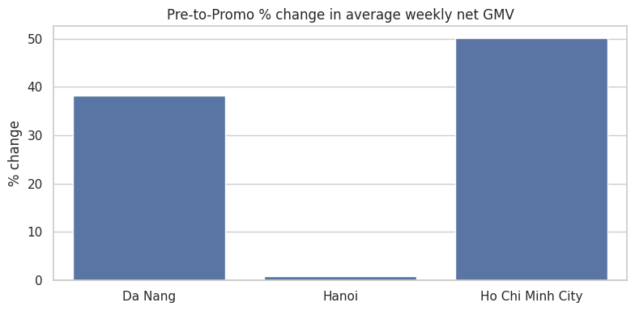

```python
plot_df = city_delta[["city", "avg_weekly_net_gmv_pct_change"]].copy()
plot_df["avg_weekly_net_gmv_pct_change"] *= 100

plt.figure(figsize=(8,4))
sns.barplot(data=plot_df, x="city", y="avg_weekly_net_gmv_pct_change")
plt.axhline(0, color="black", linewidth=1)
plt.title("Pre-to-Promo % change in average weekly net GMV")
plt.xlabel("")
plt.ylabel("% change")
plt.tight_layout()
plt.show()
```

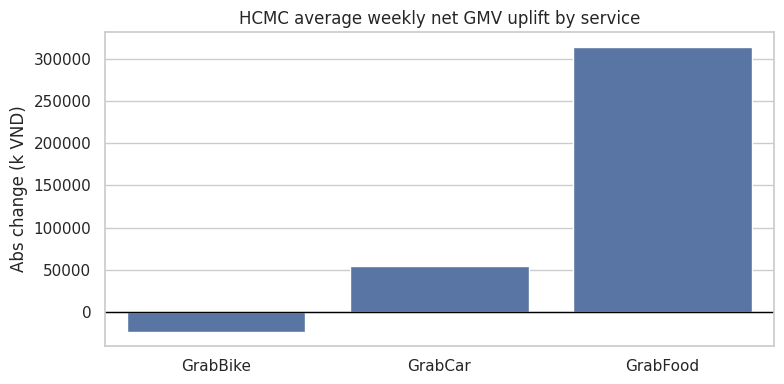

```python
plot_df = hcmc_service_delta[["service_type", "avg_weekly_net_gmv_abs_change"]].copy()

plt.figure(figsize=(8,4))
sns.barplot(data=plot_df, x="service_type", y="avg_weekly_net_gmv_abs_change")
plt.axhline(0, color="black", linewidth=1)
plt.title("HCMC average weekly net GMV uplift by service")
plt.xlabel("")
plt.ylabel("Abs change (k VND)")
plt.tight_layout()
plt.show()
```

=> The **quantified uplift** confirms that **HCMC** experienced **meaningful promo-period gains**, but the **key analytical question** is not only whether **uplift existed**, but whether it was **incremental, efficient, and sustainable** enough to justify **rollout to Hanoi**.

## Attribution Check

Difference-in-Differences Check = DIDC

### City-Level DIDC

```python
did_city = city_delta[[
    "city",
    "avg_weekly_net_gmv_abs_change",
    "avg_weekly_transactions_abs_change",
    "avg_weekly_active_users_abs_change",
    "avg_weekly_discount_rate_abs_change",
    "avg_weekly_rainfall_abs_change"
]].copy()

hcmc = did_city[did_city["city"] == "Ho Chi Minh City"].iloc[0]

did_city["did_net_gmv_vs_hcmc"] = hcmc["avg_weekly_net_gmv_abs_change"] - did_city["avg_weekly_net_gmv_abs_change"]
did_city["did_transactions_vs_hcmc"] = hcmc["avg_weekly_transactions_abs_change"] - did_city["avg_weekly_transactions_abs_change"]
did_city["did_active_users_vs_hcmc"] = hcmc["avg_weekly_active_users_abs_change"] - did_city["avg_weekly_active_users_abs_change"]
did_city["did_discount_rate_vs_hcmc"] = hcmc["avg_weekly_discount_rate_abs_change"] - did_city["avg_weekly_discount_rate_abs_change"]
did_city["did_rainfall_vs_hcmc"] = hcmc["avg_weekly_rainfall_abs_change"] - did_city["avg_weekly_rainfall_abs_change"]

display(did_city)
```

|  | city | avg_weekly_net_gmv_abs_change | avg_weekly_transactions_abs_change | avg_weekly_active_users_abs_change | avg_weekly_discount_rate_abs_change | avg_weekly_rainfall_abs_change | did_net_gmv_vs_hcmc | did_transactions_vs_hcmc | did_active_users_vs_hcmc | did_discount_rate_vs_hcmc | did_rainfall_vs_hcmc |
| --- | --- | --- | --- | --- | --- | --- | --- | --- | --- | --- | --- |
| 0 | Da Nang | 71,672.74 | 342.50 | 127.83 | 0.00 | 44.54 | 273,807.68 | 2,716.33 | 734.83 | 0.16 | 16.41 |
| 1 | Hanoi | 3,622.99 | 66.33 | 20.17 | 0.00 | -1.32 | 341,857.43 | 2,992.50 | 842.50 | 0.16 | 62.27 |
| 2 | Ho Chi Minh City | 345,480.42 | 3,058.83 | 862.67 | 0.16 | 60.95 | 0.00 | 0.00 | 0.00 | 0.00 | 0.00 |

At the city level, HCMC shows a stronger promo-period uplift than the control cities, but the estimated effect should be interpreted cautiously because concurrent market and weather differences may still influence the result.

### Service-Level DIDC

```python
service_period_summary = (
    weekly_city_service_kpi
    .groupby(["city", "service_type", "period"], observed=False)
    .agg(
        avg_weekly_net_gmv=("net_gmv_k_vnd", "mean"),
        avg_weekly_transactions=("n_transactions", "mean"),
        avg_weekly_active_users=("active_users", "mean"),
        avg_weekly_discount_rate=("discount_rate", "mean"),
        avg_weekly_rainfall=("avg_rainfall_mm", "mean")
    )
    .reset_index()
)

svc_pre = (
    service_period_summary[service_period_summary["period"] == "Pre-Promo"]
    .drop(columns="period")
    .rename(columns={
        "avg_weekly_net_gmv": "net_gmv_pre",
        "avg_weekly_transactions": "transactions_pre",
        "avg_weekly_active_users": "active_users_pre",
        "avg_weekly_discount_rate": "discount_rate_pre",
        "avg_weekly_rainfall": "rainfall_pre"
    })
)

svc_promo = (
    service_period_summary[service_period_summary["period"] == "Promo"]
    .drop(columns="period")
    .rename(columns={
        "avg_weekly_net_gmv": "net_gmv_promo",
        "avg_weekly_transactions": "transactions_promo",
        "avg_weekly_active_users": "active_users_promo",
        "avg_weekly_discount_rate": "discount_rate_promo",
        "avg_weekly_rainfall": "rainfall_promo"
    })
)

did_service = svc_pre.merge(svc_promo, on=["city", "service_type"], how="inner")

for col in ["net_gmv", "transactions", "active_users", "discount_rate", "rainfall"]:
    did_service[f"{col}_change"] = did_service[f"{col}_promo"] - did_service[f"{col}_pre"]

display(did_service.head(12))
```

|  | city | service_type | net_gmv_pre | transactions_pre | active_users_pre | discount_rate_pre | rainfall_pre | net_gmv_promo | transactions_promo | active_users_promo | discount_rate_promo | rainfall_promo | net_gmv_change | transactions_change | active_users_change | discount_rate_change | rainfall_change |
| --- | --- | --- | --- | --- | --- | --- | --- | --- | --- | --- | --- | --- | --- | --- | --- | --- | --- |
| 0 | Da Nang | GrabBike | 23,180.93 | 626.00 | 529.17 | 0.00 | 5.51 | 17,468.22 | 473.33 | 412.00 | 0.00 | 47.31 | -5,712.71 | -152.67 | -117.17 | 0.00 | 41.80 |
| 1 | Da Nang | GrabCar | 22,302.56 | 172.17 | 166.17 | 0.00 | 5.96 | 37,594.01 | 289.00 | 267.17 | 0.00 | 51.92 | 15,291.44 | 116.83 | 101.00 | 0.00 | 45.96 |
| 2 | Da Nang | GrabFood | 142,440.42 | 860.33 | 682.00 | 0.00 | 5.90 | 204,534.42 | 1,238.67 | 897.67 | 0.00 | 51.08 | 62,094.00 | 378.33 | 215.67 | 0.00 | 45.19 |
| 3 | Hanoi | GrabBike | 56,172.78 | 1,516.17 | 1,256.67 | 0.00 | 3.55 | 58,162.18 | 1,572.17 | 1,292.17 | 0.00 | 2.27 | 1,989.39 | 56.00 | 35.50 | 0.00 | -1.27 |
| 4 | Hanoi | GrabCar | 57,948.53 | 446.67 | 424.83 | 0.00 | 3.63 | 57,709.15 | 442.00 | 421.83 | 0.00 | 2.22 | -239.38 | -4.67 | -3.00 | 0.00 | -1.40 |
| 5 | Hanoi | GrabFood | 325,076.75 | 1,972.17 | 1,555.67 | 0.00 | 3.61 | 326,949.72 | 1,987.17 | 1,570.67 | 0.00 | 2.27 | 1,872.97 | 15.00 | 15.00 | 0.00 | -1.34 |
| 6 | Ho Chi Minh City | GrabBike | 81,563.67 | 2,203.00 | 1,860.33 | 0.00 | 4.10 | 58,120.86 | 1,807.17 | 1,545.83 | 0.13 | 61.91 | -23,442.80 | -395.83 | -314.50 | 0.13 | 57.81 |
| 7 | Ho Chi Minh City | GrabCar | 79,394.32 | 610.17 | 582.17 | 0.00 | 4.59 | 133,597.24 | 1,028.67 | 941.00 | 0.00 | 67.14 | 54,202.92 | 418.50 | 358.83 | 0.00 | 62.55 |
| 8 | Ho Chi Minh City | GrabFood | 529,081.01 | 3,211.67 | 2,488.17 | 0.00 | 4.57 | 843,801.31 | 6,247.83 | 3,891.50 | 0.18 | 66.11 | 314,720.30 | 3,036.17 | 1,403.33 | 0.18 | 61.54 |

```python
hcmc_svc = did_service[did_service["city"] == "Ho Chi Minh City"].copy()
control_svc = did_service[did_service["city"].isin(["Hanoi", "Da Nang"])].copy()

did_service_compare = control_svc.merge(
    hcmc_svc[["service_type", "net_gmv_change", "transactions_change", "active_users_change", "discount_rate_change", "rainfall_change"]],
    on="service_type",
    suffixes=("_control", "_hcmc")
)

for col in ["net_gmv_change", "transactions_change", "active_users_change", "discount_rate_change", "rainfall_change"]:
    did_service_compare[f"did_{col}"] = (
        did_service_compare[f"{col}_hcmc"] - did_service_compare[f"{col}_control"]
    )

display(did_service_compare.sort_values(["service_type", "city"]))
```

|  | city | service_type | net_gmv_pre | transactions_pre | active_users_pre | discount_rate_pre | rainfall_pre | net_gmv_promo | transactions_promo | active_users_promo | discount_rate_promo | rainfall_promo | net_gmv_change_control | transactions_change_control | active_users_change_control | discount_rate_change_control | rainfall_change_control | net_gmv_change_hcmc | transactions_change_hcmc | active_users_change_hcmc | discount_rate_change_hcmc | rainfall_change_hcmc | did_net_gmv_change | did_transactions_change | did_active_users_change | did_discount_rate_change | did_rainfall_change |
| --- | --- | --- | --- | --- | --- | --- | --- | --- | --- | --- | --- | --- | --- | --- | --- | --- | --- | --- | --- | --- | --- | --- | --- | --- | --- | --- | --- |
| 0 | Da Nang | GrabBike | 23,180.93 | 626.00 | 529.17 | 0.00 | 5.51 | 17,468.22 | 473.33 | 412.00 | 0.00 | 47.31 | -5,712.71 | -152.67 | -117.17 | 0.00 | 41.80 | -23,442.80 | -395.83 | -314.50 | 0.13 | 57.81 | -17,730.09 | -243.17 | -197.33 | 0.13 | 16.01 |
| 3 | Hanoi | GrabBike | 56,172.78 | 1,516.17 | 1,256.67 | 0.00 | 3.55 | 58,162.18 | 1,572.17 | 1,292.17 | 0.00 | 2.27 | 1,989.39 | 56.00 | 35.50 | 0.00 | -1.27 | -23,442.80 | -395.83 | -314.50 | 0.13 | 57.81 | -25,432.20 | -451.83 | -350.00 | 0.13 | 59.08 |
| 1 | Da Nang | GrabCar | 22,302.56 | 172.17 | 166.17 | 0.00 | 5.96 | 37,594.01 | 289.00 | 267.17 | 0.00 | 51.92 | 15,291.44 | 116.83 | 101.00 | 0.00 | 45.96 | 54,202.92 | 418.50 | 358.83 | 0.00 | 62.55 | 38,911.47 | 301.67 | 257.83 | 0.00 | 16.59 |
| 4 | Hanoi | GrabCar | 57,948.53 | 446.67 | 424.83 | 0.00 | 3.63 | 57,709.15 | 442.00 | 421.83 | 0.00 | 2.22 | -239.38 | -4.67 | -3.00 | 0.00 | -1.40 | 54,202.92 | 418.50 | 358.83 | 0.00 | 62.55 | 54,442.30 | 423.17 | 361.83 | 0.00 | 63.96 |
| 2 | Da Nang | GrabFood | 142,440.42 | 860.33 | 682.00 | 0.00 | 5.90 | 204,534.42 | 1,238.67 | 897.67 | 0.00 | 51.08 | 62,094.00 | 378.33 | 215.67 | 0.00 | 45.19 | 314,720.30 | 3,036.17 | 1,403.33 | 0.18 | 61.54 | 252,626.30 | 2,657.83 | 1,187.67 | 0.18 | 16.36 |
| 5 | Hanoi | GrabFood | 325,076.75 | 1,972.17 | 1,555.67 | 0.00 | 3.61 | 326,949.72 | 1,987.17 | 1,570.67 | 0.00 | 2.27 | 1,872.97 | 15.00 | 15.00 | 0.00 | -1.34 | 314,720.30 | 3,036.17 | 1,403.33 | 0.18 | 61.54 | 312,847.33 | 3,021.17 | 1,388.33 | 0.18 | 62.88 |

At the service level, the estimated incremental effect appears concentrated in GrabFood rather than spread evenly across services, suggesting that the promo impact was service-skewed rather than a balanced combo effect.

### City-Level Rainfall Impact Analysis

```python
df_txn_rain = df_transactions.copy()

df_txn_rain["rain_bucket"] = pd.cut(
    df_txn_rain["rainfall_mm"],
    bins=[-0.1, 0.1, 10, 50, 1e9],
    labels=["No rain", "Light", "Moderate", "Heavy"]
)

rain_impact_city = (
    df_txn_rain
    .groupby(["city", "rain_bucket"], observed=False)
    .agg(
        n_transactions=("transaction_id", "count"),
        active_users=("user_id", "nunique"),
        net_gmv_k_vnd=("net_gmv_k_vnd", "sum")
    )
    .reset_index()
)

rain_impact_city["net_gmv_per_txn"] = rain_impact_city["net_gmv_k_vnd"] / rain_impact_city["n_transactions"]

display(rain_impact_city)
```

|  | city | rain_bucket | n_transactions | active_users | net_gmv_k_vnd | net_gmv_per_txn |
| --- | --- | --- | --- | --- | --- | --- |
| 0 | Ho Chi Minh City | No rain | 0 | 0 | 0.00 | NaN |
| 1 | Ho Chi Minh City | Light | 40136 | 5993 | 4,529,051.22 | 112.84 |
| 2 | Ho Chi Minh City | Moderate | 27689 | 5933 | 3,166,269.12 | 114.35 |
| 3 | Ho Chi Minh City | Heavy | 33365 | 5976 | 3,856,205.97 | 115.58 |
| 4 | Hanoi | No rain | 3399 | 2264 | 372,252.73 | 109.52 |
| 5 | Hanoi | Light | 51310 | 4000 | 5,705,631.95 | 111.20 |
| 6 | Hanoi | Moderate | 1151 | 1016 | 131,800.81 | 114.51 |
| 7 | Hanoi | Heavy | 0 | 0 | 0.00 | NaN |
| 8 | Da Nang | No rain | 0 | 0 | 0.00 | NaN |
| 9 | Da Nang | Light | 12464 | 1797 | 1,398,421.00 | 112.20 |
| 10 | Da Nang | Moderate | 7799 | 1774 | 994,585.39 | 127.53 |
| 11 | Da Nang | Heavy | 5000 | 1679 | 665,287.03 | 133.06 |

Rainfall appears to be an important co-driver of city-level performance, indicating that part of HCMC’s observed uplift may reflect weather-supported demand rather than promo impact alone.

### Service-Level Rainfall Impact Analysis

```python
rain_impact_service = (
    df_txn_rain
    .groupby(["city", "service_type", "rain_bucket"], observed=False)
    .agg(
        n_transactions=("transaction_id", "count"),
        active_users=("user_id", "nunique"),
        net_gmv_k_vnd=("net_gmv_k_vnd", "sum")
    )
    .reset_index()
)

rain_impact_service["net_gmv_per_txn"] = (
    rain_impact_service["net_gmv_k_vnd"] / rain_impact_service["n_transactions"]
)

display(rain_impact_service.head(20))
```

|  | city | service_type | rain_bucket | n_transactions | active_users | net_gmv_k_vnd | net_gmv_per_txn |
| --- | --- | --- | --- | --- | --- | --- | --- |
| 0 | Ho Chi Minh City | GrabBike | No rain | 0 | 0 | 0.00 | NaN |
| 1 | Ho Chi Minh City | GrabBike | Light | 15261 | 5568 | 564,945.44 | 37.02 |
| 2 | Ho Chi Minh City | GrabBike | Moderate | 6564 | 3979 | 220,515.50 | 33.59 |
| 3 | Ho Chi Minh City | GrabBike | Heavy | 6146 | 3844 | 197,715.45 | 32.17 |
| 4 | Ho Chi Minh City | GrabCar | No rain | 0 | 0 | 0.00 | NaN |
| 5 | Ho Chi Minh City | GrabCar | Light | 3957 | 2873 | 514,225.58 | 129.95 |
| 6 | Ho Chi Minh City | GrabCar | Moderate | 3002 | 2370 | 390,239.01 | 129.99 |
| 7 | Ho Chi Minh City | GrabCar | Heavy | 3944 | 2901 | 511,251.80 | 129.63 |
| 8 | Ho Chi Minh City | GrabFood | No rain | 0 | 0 | 0.00 | NaN |
| 9 | Ho Chi Minh City | GrabFood | Light | 20918 | 5812 | 3,449,880.20 | 164.92 |
| 10 | Ho Chi Minh City | GrabFood | Moderate | 18123 | 5717 | 2,555,514.61 | 141.01 |
| 11 | Ho Chi Minh City | GrabFood | Heavy | 23275 | 5878 | 3,147,238.72 | 135.22 |
| 12 | Hanoi | GrabBike | No rain | 1355 | 1147 | 49,962.71 | 36.87 |
| 13 | Hanoi | GrabBike | Light | 19972 | 3982 | 739,948.01 | 37.05 |
| 14 | Hanoi | GrabBike | Moderate | 410 | 389 | 15,170.39 | 37.00 |
| 15 | Hanoi | GrabBike | Heavy | 0 | 0 | 0.00 | NaN |
| 16 | Hanoi | GrabCar | No rain | 385 | 373 | 50,148.02 | 130.25 |
| 17 | Hanoi | GrabCar | Light | 5666 | 3024 | 737,130.23 | 130.10 |
| 18 | Hanoi | GrabCar | Moderate | 154 | 152 | 20,131.45 | 130.72 |
| 19 | Hanoi | GrabCar | Heavy | 0 | 0 | 0.00 | NaN |

The rainfall effect is strongest in delivery-related activity, especially GrabFood, which suggests that service-level promo uplift in HCMC may be partly confounded by weather-driven usage patterns.

## Rainfall-Normalized Impact Analysis

### Daily City-Service Weather Table

```python
# Daily service-level demand joined with official rain category
daily_service_weather = (
    df_transactions
    .groupby(["date", "city", "period", "service_type"], observed=False)
    .agg(
        n_transactions=("transaction_id", "count"),
        active_users=("user_id", "nunique"),
        net_gmv_k_vnd=("net_gmv_k_vnd", "sum"),
        gross_gmv_k_vnd=("gross_gmv_k_vnd", "sum"),
        discount_k_vnd=("discount_k_vnd", "sum")
    )
    .reset_index()
    .merge(
        df_weather_daily[["date", "city", "rain_category", "rainfall_mm"]],
        on=["date", "city"],
        how="left"
    )
)

daily_service_weather["rain_category"] = daily_service_weather["rain_category"].fillna("None")
daily_service_weather["rain_category"] = pd.Categorical(
    daily_service_weather["rain_category"],
    categories=["None", "Light", "Moderate", "Heavy"],
    ordered=True
)

daily_service_weather["net_gmv_per_txn"] = (
    daily_service_weather["net_gmv_k_vnd"] / daily_service_weather["n_transactions"]
)
daily_service_weather["discount_rate"] = np.where(
    daily_service_weather["gross_gmv_k_vnd"] > 0,
    daily_service_weather["discount_k_vnd"] / daily_service_weather["gross_gmv_k_vnd"],
    np.nan
)

daily_service_weather.head(10)
```

|  | date | city | period | service_type | n_transactions | active_users | net_gmv_k_vnd | gross_gmv_k_vnd | discount_k_vnd | rain_category | rainfall_mm | net_gmv_per_txn | discount_rate |
| --- | --- | --- | --- | --- | --- | --- | --- | --- | --- | --- | --- | --- | --- |
| 0 | 2024-01-01 | Ho Chi Minh City | Pre-Promo | GrabBike | 310 | 305 | 11,471.84 | 11,471.84 | 0.00 | None | 1.60 | 37.01 | 0.00 |
| 1 | 2024-01-01 | Ho Chi Minh City | Pre-Promo | GrabCar | 82 | 78 | 10,905.55 | 10,905.55 | 0.00 | None | 1.60 | 132.99 | 0.00 |
| 2 | 2024-01-01 | Ho Chi Minh City | Pre-Promo | GrabFood | 407 | 396 | 66,366.49 | 66,366.49 | 0.00 | None | 1.60 | 163.06 | 0.00 |
| 3 | 2024-01-01 | Ho Chi Minh City | Promo | GrabBike | 0 | 0 | 0.00 | 0.00 | 0.00 | None | 1.60 | NaN | NaN |
| 4 | 2024-01-01 | Ho Chi Minh City | Promo | GrabCar | 0 | 0 | 0.00 | 0.00 | 0.00 | None | 1.60 | NaN | NaN |
| 5 | 2024-01-01 | Ho Chi Minh City | Promo | GrabFood | 0 | 0 | 0.00 | 0.00 | 0.00 | None | 1.60 | NaN | NaN |
| 6 | 2024-01-01 | Ho Chi Minh City | Post-Promo | GrabBike | 0 | 0 | 0.00 | 0.00 | 0.00 | None | 1.60 | NaN | NaN |
| 7 | 2024-01-01 | Ho Chi Minh City | Post-Promo | GrabCar | 0 | 0 | 0.00 | 0.00 | 0.00 | None | 1.60 | NaN | NaN |
| 8 | 2024-01-01 | Ho Chi Minh City | Post-Promo | GrabFood | 0 | 0 | 0.00 | 0.00 | 0.00 | None | 1.60 | NaN | NaN |
| 9 | 2024-01-01 | Hanoi | Pre-Promo | GrabBike | 220 | 215 | 8,062.35 | 8,062.35 | 0.00 | None | 1.70 | 36.65 | 0.00 |

### Normalizing for Weather Effects

```python
weather_normalized = (
    daily_service_weather
    .groupby(["city", "service_type", "rain_category"], observed=False)
    .agg(
        n_days=("date", "nunique"),
        avg_daily_transactions=("n_transactions", "mean"),
        avg_daily_active_users=("active_users", "mean"),
        avg_daily_net_gmv=("net_gmv_k_vnd", "mean"),
        avg_daily_net_gmv_per_txn=("net_gmv_per_txn", "mean"),
        avg_daily_discount_rate=("discount_rate", "mean")
    )
    .reset_index()
)

weather_normalized.head()
```

|  | city | service_type | rain_category | n_days | avg_daily_transactions | avg_daily_active_users | avg_daily_net_gmv | avg_daily_net_gmv_per_txn | avg_daily_discount_rate |
| --- | --- | --- | --- | --- | --- | --- | --- | --- | --- |
| 0 | Ho Chi Minh City | GrabBike | None | 26 | 104.56 | 102.05 | 3,871.97 | 37.03 | 0.00 |
| 1 | Ho Chi Minh City | GrabBike | Light | 23 | 102.97 | 100.00 | 3,810.60 | 37.01 | 0.00 |
| 2 | Ho Chi Minh City | GrabBike | Moderate | 16 | 96.12 | 93.52 | 3,287.99 | 34.36 | 0.07 |
| 3 | Ho Chi Minh City | GrabBike | Heavy | 33 | 81.78 | 80.20 | 2,630.38 | 32.16 | 0.13 |
| 4 | Ho Chi Minh City | GrabCar | None | 26 | 26.85 | 26.63 | 3,489.30 | 129.93 | 0.00 |

## Create a "lift" table from Light -> Moderate / Heavy

The lift table is used to estimate how much demand increases under heavier rain and to separate weather-driven uplift from promo-driven uplift.

```python
txn_pivot = weather_normalized.pivot_table(
    index=["city", "service_type"],
    columns="rain_category",
    values="avg_daily_transactions"
)
txn_pivot
```

| city | rain_category service_type | None | Light | Moderate | Heavy |
| --- | --- | --- | --- | --- | --- |
| Ho Chi Minh City | GrabBike | 104.56 | 102.97 | 96.12 | 81.78 |
|  | GrabCar | 26.85 | 27.00 | 36.65 | 52.39 |
|  | GrabFood | 142.91 | 141.61 | 221.98 | 310.54 |
| Hanoi | GrabBike | 73.99 | 73.88 | NaN | NaN |
|  | GrabCar | 21.23 | 20.99 | NaN | NaN |
|  | GrabFood | 94.26 | 95.60 | NaN | NaN |
| Da Nang | GrabBike | 30.52 | 30.04 | 26.17 | 20.48 |
|  | GrabCar | 7.82 | 8.08 | 10.69 | 15.31 |
|  | GrabFood | 39.77 | 40.28 | 51.78 | 62.60 |

```python
gmv_pivot = weather_normalized.pivot_table(
    index=["city", "service_type"],
    columns="rain_category",
    values="avg_daily_net_gmv"
)
gmv_pivot
```

| city | rain_category service_type | None | Light | Moderate | Heavy |
| --- | --- | --- | --- | --- | --- |
| Ho Chi Minh City | GrabBike | 3,871.97 | 3,810.60 | 3,287.99 | 2,630.38 |
|  | GrabCar | 3,489.30 | 3,508.12 | 4,758.25 | 6,798.94 |
|  | GrabFood | 23,531.52 | 23,397.42 | 32,244.51 | 41,969.86 |
| Hanoi | GrabBike | 2,734.49 | 2,741.95 | NaN | NaN |
|  | GrabCar | 2,766.22 | 2,727.92 | NaN | NaN |
|  | GrabFood | 15,538.55 | 15,727.18 | NaN | NaN |
| Da Nang | GrabBike | 1,127.22 | 1,114.60 | 968.87 | 753.90 |
|  | GrabCar | 1,017.42 | 1,046.93 | 1,379.16 | 1,994.96 |
|  | GrabFood | 6,637.28 | 6,626.36 | 8,536.88 | 10,345.85 |

```python
aov_pivot = weather_normalized.pivot_table(
    index=["city", "service_type"],
    columns="rain_category",
    values="avg_daily_net_gmv_per_txn"
)
aov_pivot
```

| city | rain_category service_type | None | Light | Moderate | Heavy |
| --- | --- | --- | --- | --- | --- |
| Ho Chi Minh City | GrabBike | 37.03 | 37.01 | 34.36 | 32.16 |
|  | GrabCar | 129.93 | 129.96 | 129.71 | 129.77 |
|  | GrabFood | 164.61 | 165.19 | 147.29 | 135.14 |
| Hanoi | GrabBike | 36.96 | 37.12 | NaN | NaN |
|  | GrabCar | 130.32 | 129.91 | NaN | NaN |
|  | GrabFood | 164.79 | 164.52 | NaN | NaN |
| Da Nang | GrabBike | 36.96 | 37.09 | 37.02 | 36.81 |
|  | GrabCar | 130.28 | 129.44 | 129.04 | 130.26 |
|  | GrabFood | 167.00 | 164.46 | 164.83 | 165.27 |

```python
weather_lift = (
    txn_pivot.add_prefix("txn_")
    .join(gmv_pivot.add_prefix("gmv_"))
    .join(aov_pivot.add_prefix("aov_"))
    .reset_index()
)
weather_lift
```

| rain_category | city | service_type | txn_None | txn_Light | txn_Moderate | txn_Heavy | gmv_None | gmv_Light | gmv_Moderate | gmv_Heavy | aov_None | aov_Light | aov_Moderate | aov_Heavy |
| --- | --- | --- | --- | --- | --- | --- | --- | --- | --- | --- | --- | --- | --- | --- |
| 0 | Ho Chi Minh City | GrabBike | 104.56 | 102.97 | 96.12 | 81.78 | 3,871.97 | 3,810.60 | 3,287.99 | 2,630.38 | 37.03 | 37.01 | 34.36 | 32.16 |
| 1 | Ho Chi Minh City | GrabCar | 26.85 | 27.00 | 36.65 | 52.39 | 3,489.30 | 3,508.12 | 4,758.25 | 6,798.94 | 129.93 | 129.96 | 129.71 | 129.77 |
| 2 | Ho Chi Minh City | GrabFood | 142.91 | 141.61 | 221.98 | 310.54 | 23,531.52 | 23,397.42 | 32,244.51 | 41,969.86 | 164.61 | 165.19 | 147.29 | 135.14 |
| 3 | Hanoi | GrabBike | 73.99 | 73.88 | NaN | NaN | 2,734.49 | 2,741.95 | NaN | NaN | 36.96 | 37.12 | NaN | NaN |
| 4 | Hanoi | GrabCar | 21.23 | 20.99 | NaN | NaN | 2,766.22 | 2,727.92 | NaN | NaN | 130.32 | 129.91 | NaN | NaN |
| 5 | Hanoi | GrabFood | 94.26 | 95.60 | NaN | NaN | 15,538.55 | 15,727.18 | NaN | NaN | 164.79 | 164.52 | NaN | NaN |
| 6 | Da Nang | GrabBike | 30.52 | 30.04 | 26.17 | 20.48 | 1,127.22 | 1,114.60 | 968.87 | 753.90 | 36.96 | 37.09 | 37.02 | 36.81 |
| 7 | Da Nang | GrabCar | 7.82 | 8.08 | 10.69 | 15.31 | 1,017.42 | 1,046.93 | 1,379.16 | 1,994.96 | 130.28 | 129.44 | 129.04 | 130.26 |
| 8 | Da Nang | GrabFood | 39.77 | 40.28 | 51.78 | 62.60 | 6,637.28 | 6,626.36 | 8,536.88 | 10,345.85 | 167.00 | 164.46 | 164.83 | 165.27 |

```python
for metric_prefix in ["txn", "gmv", "aov"]:
    weather_lift[f"{metric_prefix}_moderate_vs_light_ratio"] = (
        weather_lift[f"{metric_prefix}_Moderate"] / weather_lift[f"{metric_prefix}_Light"]
    )
    weather_lift[f"{metric_prefix}_heavy_vs_light_ratio"] = (
        weather_lift[f"{metric_prefix}_Heavy"] / weather_lift[f"{metric_prefix}_Light"]
    )

display(weather_lift.head(10))
```

| rain_category | city | service_type | txn_None | txn_Light | txn_Moderate | txn_Heavy | gmv_None | gmv_Light | gmv_Moderate | gmv_Heavy | aov_None | aov_Light | aov_Moderate | aov_Heavy | txn_moderate_vs_light_ratio | txn_heavy_vs_light_ratio | gmv_moderate_vs_light_ratio | gmv_heavy_vs_light_ratio | aov_moderate_vs_light_ratio | aov_heavy_vs_light_ratio |
| --- | --- | --- | --- | --- | --- | --- | --- | --- | --- | --- | --- | --- | --- | --- | --- | --- | --- | --- | --- | --- |
| 0 | Ho Chi Minh City | GrabBike | 104.56 | 102.97 | 96.12 | 81.78 | 3,871.97 | 3,810.60 | 3,287.99 | 2,630.38 | 37.03 | 37.01 | 34.36 | 32.16 | 0.93 | 0.79 | 0.86 | 0.69 | 0.93 | 0.87 |
| 1 | Ho Chi Minh City | GrabCar | 26.85 | 27.00 | 36.65 | 52.39 | 3,489.30 | 3,508.12 | 4,758.25 | 6,798.94 | 129.93 | 129.96 | 129.71 | 129.77 | 1.36 | 1.94 | 1.36 | 1.94 | 1.00 | 1.00 |
| 2 | Ho Chi Minh City | GrabFood | 142.91 | 141.61 | 221.98 | 310.54 | 23,531.52 | 23,397.42 | 32,244.51 | 41,969.86 | 164.61 | 165.19 | 147.29 | 135.14 | 1.57 | 2.19 | 1.38 | 1.79 | 0.89 | 0.82 |
| 3 | Hanoi | GrabBike | 73.99 | 73.88 | NaN | NaN | 2,734.49 | 2,741.95 | NaN | NaN | 36.96 | 37.12 | NaN | NaN | NaN | NaN | NaN | NaN | NaN | NaN |
| 4 | Hanoi | GrabCar | 21.23 | 20.99 | NaN | NaN | 2,766.22 | 2,727.92 | NaN | NaN | 130.32 | 129.91 | NaN | NaN | NaN | NaN | NaN | NaN | NaN | NaN |
| 5 | Hanoi | GrabFood | 94.26 | 95.60 | NaN | NaN | 15,538.55 | 15,727.18 | NaN | NaN | 164.79 | 164.52 | NaN | NaN | NaN | NaN | NaN | NaN | NaN | NaN |
| 6 | Da Nang | GrabBike | 30.52 | 30.04 | 26.17 | 20.48 | 1,127.22 | 1,114.60 | 968.87 | 753.90 | 36.96 | 37.09 | 37.02 | 36.81 | 0.87 | 0.68 | 0.87 | 0.68 | 1.00 | 0.99 |
| 7 | Da Nang | GrabCar | 7.82 | 8.08 | 10.69 | 15.31 | 1,017.42 | 1,046.93 | 1,379.16 | 1,994.96 | 130.28 | 129.44 | 129.04 | 130.26 | 1.32 | 1.89 | 1.32 | 1.91 | 1.00 | 1.01 |
| 8 | Da Nang | GrabFood | 39.77 | 40.28 | 51.78 | 62.60 | 6,637.28 | 6,626.36 | 8,536.88 | 10,345.85 | 167.00 | 164.46 | 164.83 | 165.27 | 1.29 | 1.55 | 1.29 | 1.56 | 1.00 | 1.00 |

=> The **lift table** shows that **heavier rainfall** is associated with a **strong increase in GrabFood demand**, especially in **HCMC**, where **transactions** on **heavy-rain days** are about **2.19x** light-rain levels and **GMV** reaches about **1.79x**. By contrast, **GrabBike** weakens as **rain intensifies**, while **GrabCar** improves, indicating that part of **HCMC’s observed promo uplift** is likely amplified by **weather-driven service mix shifts** rather than by **voucher effects alone**.

## Weather-Normalized Daily KPIs

### Ha Noi VS Ho Chi Minh

```python
weather_normalized_hcmc_hn= weather_normalized[
    weather_normalized["city"].isin(["Ho Chi Minh City", "Hanoi"])
].copy()

display(weather_normalized_hcmc_hn.sort_values(["service_type", "city", "rain_category"]))
```

|  | city | service_type | rain_category | n_days | avg_daily_transactions | avg_daily_active_users | avg_daily_net_gmv | avg_daily_net_gmv_per_txn | avg_daily_discount_rate |
| --- | --- | --- | --- | --- | --- | --- | --- | --- | --- |
| 0 | Ho Chi Minh City | GrabBike | None | 26 | 104.56 | 102.05 | 3,871.97 | 37.03 | 0.00 |
| 1 | Ho Chi Minh City | GrabBike | Light | 23 | 102.97 | 100.00 | 3,810.60 | 37.01 | 0.00 |
| 2 | Ho Chi Minh City | GrabBike | Moderate | 16 | 96.12 | 93.52 | 3,287.99 | 34.36 | 0.07 |
| 3 | Ho Chi Minh City | GrabBike | Heavy | 33 | 81.78 | 80.20 | 2,630.38 | 32.16 | 0.13 |
| 12 | Hanoi | GrabBike | None | 47 | 73.99 | 71.74 | 2,734.49 | 36.96 | 0.00 |
| 13 | Hanoi | GrabBike | Light | 51 | 73.88 | 71.71 | 2,741.95 | 37.12 | 0.00 |
| 14 | Hanoi | GrabBike | Moderate | 0 | NaN | NaN | NaN | NaN | NaN |
| 15 | Hanoi | GrabBike | Heavy | 0 | NaN | NaN | NaN | NaN | NaN |
| 4 | Ho Chi Minh City | GrabCar | None | 26 | 26.85 | 26.63 | 3,489.30 | 129.93 | 0.00 |
| 5 | Ho Chi Minh City | GrabCar | Light | 23 | 27.00 | 26.81 | 3,508.12 | 129.96 | 0.00 |
| 6 | Ho Chi Minh City | GrabCar | Moderate | 16 | 36.65 | 36.33 | 4,758.25 | 129.71 | 0.00 |
| 7 | Ho Chi Minh City | GrabCar | Heavy | 33 | 52.39 | 51.70 | 6,798.94 | 129.77 | 0.00 |
| 16 | Hanoi | GrabCar | None | 47 | 21.23 | 21.09 | 2,766.22 | 130.32 | 0.00 |
| 17 | Hanoi | GrabCar | Light | 51 | 20.99 | 20.83 | 2,727.92 | 129.91 | 0.00 |
| 18 | Hanoi | GrabCar | Moderate | 0 | NaN | NaN | NaN | NaN | NaN |
| 19 | Hanoi | GrabCar | Heavy | 0 | NaN | NaN | NaN | NaN | NaN |
| 8 | Ho Chi Minh City | GrabFood | None | 26 | 142.91 | 138.00 | 23,531.52 | 164.61 | 0.00 |
| 9 | Ho Chi Minh City | GrabFood | Light | 23 | 141.61 | 137.03 | 23,397.42 | 165.19 | 0.00 |
| 10 | Ho Chi Minh City | GrabFood | Moderate | 16 | 221.98 | 209.38 | 32,244.51 | 147.29 | 0.10 |
| 11 | Ho Chi Minh City | GrabFood | Heavy | 33 | 310.54 | 287.52 | 41,969.86 | 135.14 | 0.18 |
| 20 | Hanoi | GrabFood | None | 47 | 94.26 | 91.07 | 15,538.55 | 164.79 | 0.00 |
| 21 | Hanoi | GrabFood | Light | 51 | 95.60 | 92.41 | 15,727.18 | 164.52 | 0.00 |
| 22 | Hanoi | GrabFood | Moderate | 0 | NaN | NaN | NaN | NaN | NaN |
| 23 | Hanoi | GrabFood | Heavy | 0 | NaN | NaN | NaN | NaN | NaN |

After normalizing for rainfall conditions, HCMC still shows stronger daily KPI performance than Hanoi, but the adjusted gap is narrower, indicating that part of the observed HCMC uplift was supported by weather rather than by promo alone.

### Ho Chi Minh VS Da Nang

```python
weather_normalized_hcmc_dn = weather_normalized[
    weather_normalized["city"].isin(["Ho Chi Minh City", "Da Nang"])
].copy()

display(weather_normalized_hcmc_dn.sort_values(["service_type", "city", "rain_category"]))
```

|  | city | service_type | rain_category | n_days | avg_daily_transactions | avg_daily_active_users | avg_daily_net_gmv | avg_daily_net_gmv_per_txn | avg_daily_discount_rate |
| --- | --- | --- | --- | --- | --- | --- | --- | --- | --- |
| 0 | Ho Chi Minh City | GrabBike | None | 26 | 104.56 | 102.05 | 3,871.97 | 37.03 | 0.00 |
| 1 | Ho Chi Minh City | GrabBike | Light | 23 | 102.97 | 100.00 | 3,810.60 | 37.01 | 0.00 |
| 2 | Ho Chi Minh City | GrabBike | Moderate | 16 | 96.12 | 93.52 | 3,287.99 | 34.36 | 0.07 |
| 3 | Ho Chi Minh City | GrabBike | Heavy | 33 | 81.78 | 80.20 | 2,630.38 | 32.16 | 0.13 |
| 24 | Da Nang | GrabBike | None | 20 | 30.52 | 29.73 | 1,127.22 | 36.96 | 0.00 |
| 25 | Da Nang | GrabBike | Light | 32 | 30.04 | 29.44 | 1,114.60 | 37.09 | 0.00 |
| 26 | Da Nang | GrabBike | Moderate | 18 | 26.17 | 25.46 | 968.87 | 37.02 | 0.00 |
| 27 | Da Nang | GrabBike | Heavy | 28 | 20.48 | 20.15 | 753.90 | 36.81 | 0.00 |
| 4 | Ho Chi Minh City | GrabCar | None | 26 | 26.85 | 26.63 | 3,489.30 | 129.93 | 0.00 |
| 5 | Ho Chi Minh City | GrabCar | Light | 23 | 27.00 | 26.81 | 3,508.12 | 129.96 | 0.00 |
| 6 | Ho Chi Minh City | GrabCar | Moderate | 16 | 36.65 | 36.33 | 4,758.25 | 129.71 | 0.00 |
| 7 | Ho Chi Minh City | GrabCar | Heavy | 33 | 52.39 | 51.70 | 6,798.94 | 129.77 | 0.00 |
| 28 | Da Nang | GrabCar | None | 20 | 7.82 | 7.80 | 1,017.42 | 130.28 | 0.00 |
| 29 | Da Nang | GrabCar | Light | 32 | 8.08 | 8.08 | 1,046.93 | 129.44 | 0.00 |
| 30 | Da Nang | GrabCar | Moderate | 18 | 10.69 | 10.57 | 1,379.16 | 129.04 | 0.00 |
| 31 | Da Nang | GrabCar | Heavy | 28 | 15.31 | 15.19 | 1,994.96 | 130.26 | 0.00 |
| 8 | Ho Chi Minh City | GrabFood | None | 26 | 142.91 | 138.00 | 23,531.52 | 164.61 | 0.00 |
| 9 | Ho Chi Minh City | GrabFood | Light | 23 | 141.61 | 137.03 | 23,397.42 | 165.19 | 0.00 |
| 10 | Ho Chi Minh City | GrabFood | Moderate | 16 | 221.98 | 209.38 | 32,244.51 | 147.29 | 0.10 |
| 11 | Ho Chi Minh City | GrabFood | Heavy | 33 | 310.54 | 287.52 | 41,969.86 | 135.14 | 0.18 |
| 32 | Da Nang | GrabFood | None | 20 | 39.77 | 38.57 | 6,637.28 | 167.00 | 0.00 |
| 33 | Da Nang | GrabFood | Light | 32 | 40.28 | 38.98 | 6,626.36 | 164.46 | 0.00 |
| 34 | Da Nang | GrabFood | Moderate | 18 | 51.78 | 49.57 | 8,536.88 | 164.83 | 0.00 |
| 35 | Da Nang | GrabFood | Heavy | 28 | 62.60 | 59.67 | 10,345.85 | 165.27 | 0.00 |

Relative to Da Nang, HCMC continues to outperform on weather-normalized daily KPIs, though the difference reduces once rainfall is accounted for. This suggests that the promo likely contributed to HCMC’s uplift, but weather also amplified the observed advantage.

=> After adjusting for **rainfall differences**, **HCMC** still outperforms the **control cities** on **daily KPIs**, but the **gap becomes narrower**. This suggests that the **promo effect** is directionally real, while part of the **observed uplift** was also amplified by **weather conditions**.

## Weather Response Comparison

### Ha Noi VS Ho Chi Minh

```python
hcmc_lift = weather_lift[weather_lift["city"] == "Ho Chi Minh City"].copy()
hn_lift = weather_lift[weather_lift["city"] == "Hanoi"].copy()

weather_lift_compare = hcmc_lift.merge(
    hn_lift,
    on="service_type",
    suffixes=("_hcmc", "_hanoi")
)

for col in [
    "txn_moderate_vs_light_ratio",
    "txn_heavy_vs_light_ratio",
    "gmv_moderate_vs_light_ratio",
    "gmv_heavy_vs_light_ratio",
    "aov_moderate_vs_light_ratio",
    "aov_heavy_vs_light_ratio"
]:
    weather_lift_compare[f"{col}_gap_hcmc_minus_hanoi"] = (
        weather_lift_compare[f"{col}_hcmc"] - weather_lift_compare[f"{col}_hanoi"]
    )

display(weather_lift_compare)
```

| rain_category | city_hcmc | service_type | txn_None_hcmc | txn_Light_hcmc | txn_Moderate_hcmc | txn_Heavy_hcmc | gmv_None_hcmc | gmv_Light_hcmc | gmv_Moderate_hcmc | gmv_Heavy_hcmc | aov_None_hcmc | aov_Light_hcmc | aov_Moderate_hcmc | aov_Heavy_hcmc | txn_moderate_vs_light_ratio_hcmc | txn_heavy_vs_light_ratio_hcmc | gmv_moderate_vs_light_ratio_hcmc | gmv_heavy_vs_light_ratio_hcmc | aov_moderate_vs_light_ratio_hcmc | aov_heavy_vs_light_ratio_hcmc | city_hanoi | txn_None_hanoi | txn_Light_hanoi | txn_Moderate_hanoi | txn_Heavy_hanoi | gmv_None_hanoi | gmv_Light_hanoi | gmv_Moderate_hanoi | gmv_Heavy_hanoi | … |
| --- | --- | --- | --- | --- | --- | --- | --- | --- | --- | --- | --- | --- | --- | --- | --- | --- | --- | --- | --- | --- | --- | --- | --- | --- | --- | --- | --- | --- | --- | --- |
| 0 | Ho Chi Minh City | GrabBike | 104.56 | 102.97 | 96.12 | 81.78 | 3,871.97 | 3,810.60 | 3,287.99 | 2,630.38 | 37.03 | 37.01 | 34.36 | 32.16 | 0.93 | 0.79 | 0.86 | 0.69 | 0.93 | 0.87 | Hanoi | 73.99 | 73.88 | NaN | NaN | 2,734.49 | 2,741.95 | NaN | NaN | … |
| 1 | Ho Chi Minh City | GrabCar | 26.85 | 27.00 | 36.65 | 52.39 | 3,489.30 | 3,508.12 | 4,758.25 | 6,798.94 | 129.93 | 129.96 | 129.71 | 129.77 | 1.36 | 1.94 | 1.36 | 1.94 | 1.00 | 1.00 | Hanoi | 21.23 | 20.99 | NaN | NaN | 2,766.22 | 2,727.92 | NaN | NaN | … |
| 2 | Ho Chi Minh City | GrabFood | 142.91 | 141.61 | 221.98 | 310.54 | 23,531.52 | 23,397.42 | 32,244.51 | 41,969.86 | 164.61 | 165.19 | 147.29 | 135.14 | 1.57 | 2.19 | 1.38 | 1.79 | 0.89 | 0.82 | Hanoi | 94.26 | 95.60 | NaN | NaN | 15,538.55 | 15,727.18 | NaN | NaN | … |

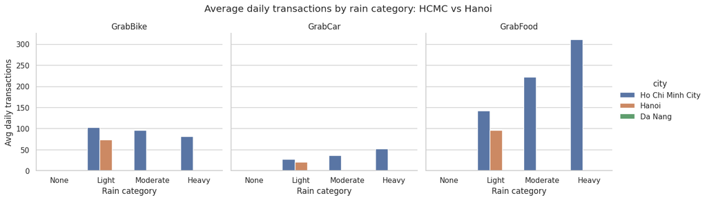

```python
plot_df = weather_normalized_hcmc_hn[
    weather_normalized_hcmc_hn["rain_category"].isin(["Light", "Moderate", "Heavy"])
].copy()

g = sns.catplot(
    data=plot_df,
    kind="bar",
    x="rain_category",
    y="avg_daily_transactions",
    hue="city",
    col="service_type",
    height=4,
    aspect=1.1
)

g.set_titles("{col_name}")
g.set_axis_labels("Rain category", "Avg daily transactions")
g.fig.suptitle("Average daily transactions by rain category: HCMC vs Hanoi", y=1.05)
plt.show()
```

Compared with Hanoi, HCMC shows a stronger weather response, especially in delivery-related demand, suggesting that part of HCMC’s observed promo-period uplift may reflect greater sensitivity to rainfall rather than promo impact alone.

### Ho Chi Minh VS Da Nang

```python
hcmc_lift = weather_lift[weather_lift["city"] == "Ho Chi Minh City"].copy()
dn_lift = weather_lift[weather_lift["city"] == "Da Nang"].copy()

weather_lift_compare = hcmc_lift.merge(
    dn_lift,
    on="service_type",
    suffixes=("_hcmc", "_danang")
)

for col in [
    "txn_moderate_vs_light_ratio",
    "txn_heavy_vs_light_ratio",
    "gmv_moderate_vs_light_ratio",
    "gmv_heavy_vs_light_ratio",
    "aov_moderate_vs_light_ratio",
    "aov_heavy_vs_light_ratio"
]:
    weather_lift_compare[f"{col}_gap_hcmc_minus_danang"] = (
        weather_lift_compare[f"{col}_hcmc"] - weather_lift_compare[f"{col}_danang"]
    )

display(weather_lift_compare)
```

| rain_category | city_hcmc | service_type | txn_None_hcmc | txn_Light_hcmc | txn_Moderate_hcmc | txn_Heavy_hcmc | gmv_None_hcmc | gmv_Light_hcmc | gmv_Moderate_hcmc | gmv_Heavy_hcmc | aov_None_hcmc | aov_Light_hcmc | aov_Moderate_hcmc | aov_Heavy_hcmc | txn_moderate_vs_light_ratio_hcmc | txn_heavy_vs_light_ratio_hcmc | gmv_moderate_vs_light_ratio_hcmc | gmv_heavy_vs_light_ratio_hcmc | aov_moderate_vs_light_ratio_hcmc | aov_heavy_vs_light_ratio_hcmc | city_danang | txn_None_danang | txn_Light_danang | txn_Moderate_danang | txn_Heavy_danang | gmv_None_danang | gmv_Light_danang | gmv_Moderate_danang | gmv_Heavy_danang | … |
| --- | --- | --- | --- | --- | --- | --- | --- | --- | --- | --- | --- | --- | --- | --- | --- | --- | --- | --- | --- | --- | --- | --- | --- | --- | --- | --- | --- | --- | --- | --- |
| 0 | Ho Chi Minh City | GrabBike | 104.56 | 102.97 | 96.12 | 81.78 | 3,871.97 | 3,810.60 | 3,287.99 | 2,630.38 | 37.03 | 37.01 | 34.36 | 32.16 | 0.93 | 0.79 | 0.86 | 0.69 | 0.93 | 0.87 | Da Nang | 30.52 | 30.04 | 26.17 | 20.48 | 1,127.22 | 1,114.60 | 968.87 | 753.90 | … |
| 1 | Ho Chi Minh City | GrabCar | 26.85 | 27.00 | 36.65 | 52.39 | 3,489.30 | 3,508.12 | 4,758.25 | 6,798.94 | 129.93 | 129.96 | 129.71 | 129.77 | 1.36 | 1.94 | 1.36 | 1.94 | 1.00 | 1.00 | Da Nang | 7.82 | 8.08 | 10.69 | 15.31 | 1,017.42 | 1,046.93 | 1,379.16 | 1,994.96 | … |
| 2 | Ho Chi Minh City | GrabFood | 142.91 | 141.61 | 221.98 | 310.54 | 23,531.52 | 23,397.42 | 32,244.51 | 41,969.86 | 164.61 | 165.19 | 147.29 | 135.14 | 1.57 | 2.19 | 1.38 | 1.79 | 0.89 | 0.82 | Da Nang | 39.77 | 40.28 | 51.78 | 62.60 | 6,637.28 | 6,626.36 | 8,536.88 | 10,345.85 | … |

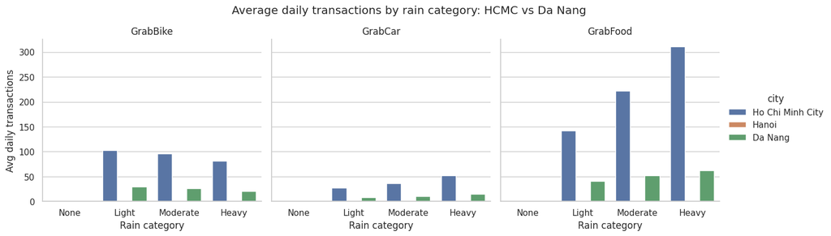

```python
plot_df = weather_normalized_hcmc_dn[
    weather_normalized_hcmc_dn["rain_category"].isin(["Light", "Moderate", "Heavy"])
].copy()

g = sns.catplot(
    data=plot_df,
    kind="bar",
    x="rain_category",
    y="avg_daily_transactions",
    hue="city",
    col="service_type",
    height=4,
    aspect=1.1
)

g.set_titles("{col_name}")
g.set_axis_labels("Rain category", "Avg daily transactions")
g.fig.suptitle("Average daily transactions by rain category: HCMC vs Da Nang", y=1.05)
plt.show()
```

Compared with Da Nang, HCMC also exhibits a stronger weather-linked shift in service mix, particularly toward GrabFood, indicating that weather likely amplified HCMC’s topline uplift more materially than in the control market.

=> The **weather response** is **not uniform** across **services** or **cities**: **heavier rainfall** consistently shifts demand toward **GrabFood** and, to a lesser extent, **GrabCar**, while **GrabBike** weakens. This indicates that **HCMC’s promo-period uplift** should be interpreted in the context of different **service sensitivities to weather**, with part of the **observed gain** likely amplified by **rain-driven demand mix**.

## Post-Promo Sustainability Check

### City-Level Persistence Across Pre, Promo, and Post

```python
city_persistence = (
    period_city_summary[[
        "period", "city",
        "avg_weekly_transactions",
        "avg_weekly_active_users",
        "avg_weekly_net_gmv",
        "avg_weekly_discount_rate",
        "avg_weekly_txns_per_user",
        "avg_weekly_net_gmv_per_txn",
        "avg_weekly_rainfall"
    ]]
    .copy()
)

display(city_persistence.sort_values(["city", "period"]))
```

|  | period | city | avg_weekly_transactions | avg_weekly_active_users | avg_weekly_net_gmv | avg_weekly_discount_rate | avg_weekly_txns_per_user | avg_weekly_net_gmv_per_txn | avg_weekly_rainfall |
| --- | --- | --- | --- | --- | --- | --- | --- | --- | --- |
| 0 | Post-Promo | Da Nang | 1,653.00 | 1,085.50 | 186,585.02 | 0.00 | 1.52 | 112.88 | 5.12 |
| 3 | Pre-Promo | Da Nang | 1,658.50 | 1,086.67 | 187,923.91 | 0.00 | 1.53 | 113.31 | 5.76 |
| 6 | Promo | Da Nang | 2,001.00 | 1,214.50 | 259,596.65 | 0.00 | 1.65 | 129.69 | 50.30 |
| 1 | Post-Promo | Hanoi | 4,121.00 | 2,582.00 | 458,785.42 | 0.00 | 1.60 | 111.33 | 2.75 |
| 4 | Pre-Promo | Hanoi | 3,935.00 | 2,503.67 | 439,198.06 | 0.00 | 1.57 | 111.62 | 3.59 |
| 7 | Promo | Hanoi | 4,001.33 | 2,523.83 | 442,821.05 | 0.00 | 1.59 | 110.66 | 2.26 |
| 2 | Post-Promo | Ho Chi Minh City | 5,269.50 | 3,520.00 | 599,087.96 | 0.00 | 1.50 | 113.69 | 5.71 |
| 5 | Pre-Promo | Ho Chi Minh City | 6,024.83 | 3,816.83 | 690,038.99 | 0.00 | 1.58 | 114.48 | 4.40 |
| 8 | Promo | Ho Chi Minh City | 9,083.67 | 4,679.50 | 1,035,519.41 | 0.16 | 1.94 | 113.99 | 65.36 |

HCMC’s KPI gains peak during promo but weaken materially in the post-promo period, indicating limited persistence once voucher support is removed.

### City-Level Post-Promo Comparison vs Pre and Promo

```python
city_pre = (
    city_persistence[city_persistence["period"] == "Pre-Promo"]
    .drop(columns="period")
    .rename(columns=lambda c: c if c == "city" else f"{c}_pre")
)

city_promo = (
    city_persistence[city_persistence["period"] == "Promo"]
    .drop(columns="period")
    .rename(columns=lambda c: c if c == "city" else f"{c}_promo")
)

city_post = (
    city_persistence[city_persistence["period"] == "Post-Promo"]
    .drop(columns="period")
    .rename(columns=lambda c: c if c == "city" else f"{c}_post")
)

city_postcheck = city_pre.merge(city_promo, on="city").merge(city_post, on="city")

for metric in [
    "avg_weekly_transactions",
    "avg_weekly_active_users",
    "avg_weekly_net_gmv",
    "avg_weekly_discount_rate",
    "avg_weekly_txns_per_user",
    "avg_weekly_net_gmv_per_txn",
    "avg_weekly_rainfall"
]:
    city_postcheck[f"{metric}_post_vs_pre_abs"] = (
        city_postcheck[f"{metric}_post"] - city_postcheck[f"{metric}_pre"]
    )
    city_postcheck[f"{metric}_post_vs_promo_abs"] = (
        city_postcheck[f"{metric}_post"] - city_postcheck[f"{metric}_promo"]
    )

display(city_postcheck)
```

|  | city | avg_weekly_transactions_pre | avg_weekly_active_users_pre | avg_weekly_net_gmv_pre | avg_weekly_discount_rate_pre | avg_weekly_txns_per_user_pre | avg_weekly_net_gmv_per_txn_pre | avg_weekly_rainfall_pre | avg_weekly_transactions_promo | avg_weekly_active_users_promo | avg_weekly_net_gmv_promo | avg_weekly_discount_rate_promo | avg_weekly_txns_per_user_promo | avg_weekly_net_gmv_per_txn_promo | avg_weekly_rainfall_promo | avg_weekly_transactions_post | avg_weekly_active_users_post | avg_weekly_net_gmv_post | avg_weekly_discount_rate_post | avg_weekly_txns_per_user_post | avg_weekly_net_gmv_per_txn_post | avg_weekly_rainfall_post | avg_weekly_transactions_post_vs_pre_abs | avg_weekly_transactions_post_vs_promo_abs | avg_weekly_active_users_post_vs_pre_abs | avg_weekly_active_users_post_vs_promo_abs | avg_weekly_net_gmv_post_vs_pre_abs | avg_weekly_net_gmv_post_vs_promo_abs | avg_weekly_discount_rate_post_vs_pre_abs | … |
| --- | --- | --- | --- | --- | --- | --- | --- | --- | --- | --- | --- | --- | --- | --- | --- | --- | --- | --- | --- | --- | --- | --- | --- | --- | --- | --- | --- | --- | --- | --- |
| 0 | Da Nang | 1,658.50 | 1,086.67 | 187,923.91 | 0.00 | 1.53 | 113.31 | 5.76 | 2,001.00 | 1,214.50 | 259,596.65 | 0.00 | 1.65 | 129.69 | 50.30 | 1,653.00 | 1,085.50 | 186,585.02 | 0.00 | 1.52 | 112.88 | 5.12 | -5.50 | -348.00 | -1.17 | -129.00 | -1,338.89 | -73,011.63 | 0.00 | … |
| 1 | Hanoi | 3,935.00 | 2,503.67 | 439,198.06 | 0.00 | 1.57 | 111.62 | 3.59 | 4,001.33 | 2,523.83 | 442,821.05 | 0.00 | 1.59 | 110.66 | 2.26 | 4,121.00 | 2,582.00 | 458,785.42 | 0.00 | 1.60 | 111.33 | 2.75 | 186.00 | 119.67 | 78.33 | 58.17 | 19,587.36 | 15,964.37 | 0.00 | … |
| 2 | Ho Chi Minh City | 6,024.83 | 3,816.83 | 690,038.99 | 0.00 | 1.58 | 114.48 | 4.40 | 9,083.67 | 4,679.50 | 1,035,519.41 | 0.16 | 1.94 | 113.99 | 65.36 | 5,269.50 | 3,520.00 | 599,087.96 | 0.00 | 1.50 | 113.69 | 5.71 | -755.33 | -3,814.17 | -296.83 | -1,159.50 | -90,951.03 | -436,431.44 | 0.00 | … |

Relative to both pre-promo and promo benchmarks, post-promo HCMC performance softens, suggesting that the observed uplift was not fully sustained after the campaign ended.

### HCMC Service-Level Persistence Across Pre, Promo, and Post

```python
hcmc_service_persistence = (
    period_city_service_summary[
        period_city_service_summary["city"] == "Ho Chi Minh City"
    ][[
        "period", "service_type",
        "avg_weekly_transactions",
        "avg_weekly_active_users",
        "avg_weekly_net_gmv",
        "avg_weekly_discount_rate",
        "avg_weekly_txns_per_user",
        "avg_weekly_net_gmv_per_txn",
        "avg_weekly_rainfall"
    ]]
    .copy()
)

display(hcmc_service_persistence.sort_values(["service_type", "period"]))
```

|  | period | service_type | avg_weekly_transactions | avg_weekly_active_users | avg_weekly_net_gmv | avg_weekly_discount_rate | avg_weekly_txns_per_user | avg_weekly_net_gmv_per_txn | avg_weekly_rainfall |
| --- | --- | --- | --- | --- | --- | --- | --- | --- | --- |
| 6 | Post-Promo | GrabBike | 1,955.00 | 1,662.50 | 72,534.60 | 0.00 | 1.18 | 37.10 | 5.29 |
| 15 | Pre-Promo | GrabBike | 2,203.00 | 1,860.33 | 81,563.67 | 0.00 | 1.18 | 37.03 | 4.10 |
| 24 | Promo | GrabBike | 1,807.17 | 1,545.83 | 58,120.86 | 0.13 | 1.17 | 32.16 | 61.91 |
| 7 | Post-Promo | GrabCar | 535.00 | 513.00 | 68,883.53 | 0.00 | 1.04 | 128.76 | 6.00 |
| 16 | Pre-Promo | GrabCar | 610.17 | 582.17 | 79,394.32 | 0.00 | 1.05 | 130.10 | 4.59 |
| 25 | Promo | GrabCar | 1,028.67 | 941.00 | 133,597.24 | 0.00 | 1.09 | 129.87 | 67.14 |
| 8 | Post-Promo | GrabFood | 2,779.50 | 2,226.00 | 457,669.83 | 0.00 | 1.25 | 164.66 | 5.93 |
| 17 | Pre-Promo | GrabFood | 3,211.67 | 2,488.17 | 529,081.01 | 0.00 | 1.29 | 164.75 | 4.57 |
| 26 | Promo | GrabFood | 6,247.83 | 3,891.50 | 843,801.31 | 0.18 | 1.61 | 135.05 | 66.11 |

At the service level, the strongest promo-period gains in HCMC do not persist evenly into post-promo, with the sharpest reversal visible in GrabFood, the main growth driver during the pilot.

### HCMC Service-Level Post-Promo Comparison

```python
svc_pre = (
    hcmc_service_persistence[hcmc_service_persistence["period"] == "Pre-Promo"]
    .drop(columns="period")
    .rename(columns=lambda c: c if c == "service_type" else f"{c}_pre")
)

svc_promo = (
    hcmc_service_persistence[hcmc_service_persistence["period"] == "Promo"]
    .drop(columns="period")
    .rename(columns=lambda c: c if c == "service_type" else f"{c}_promo")
)

svc_post = (
    hcmc_service_persistence[hcmc_service_persistence["period"] == "Post-Promo"]
    .drop(columns="period")
    .rename(columns=lambda c: c if c == "service_type" else f"{c}_post")
)

hcmc_service_postcheck = svc_pre.merge(svc_promo, on="service_type").merge(svc_post, on="service_type")

for metric in [
    "avg_weekly_transactions",
    "avg_weekly_active_users",
    "avg_weekly_net_gmv",
    "avg_weekly_discount_rate",
    "avg_weekly_txns_per_user",
    "avg_weekly_net_gmv_per_txn",
    "avg_weekly_rainfall"
]:
    hcmc_service_postcheck[f"{metric}_post_vs_pre_abs"] = (
        hcmc_service_postcheck[f"{metric}_post"] - hcmc_service_postcheck[f"{metric}_pre"]
    )
    hcmc_service_postcheck[f"{metric}_post_vs_promo_abs"] = (
        hcmc_service_postcheck[f"{metric}_post"] - hcmc_service_postcheck[f"{metric}_promo"]
    )

display(hcmc_service_postcheck)
```

|  | service_type | avg_weekly_transactions_pre | avg_weekly_active_users_pre | avg_weekly_net_gmv_pre | avg_weekly_discount_rate_pre | avg_weekly_txns_per_user_pre | avg_weekly_net_gmv_per_txn_pre | avg_weekly_rainfall_pre | avg_weekly_transactions_promo | avg_weekly_active_users_promo | avg_weekly_net_gmv_promo | avg_weekly_discount_rate_promo | avg_weekly_txns_per_user_promo | avg_weekly_net_gmv_per_txn_promo | avg_weekly_rainfall_promo | avg_weekly_transactions_post | avg_weekly_active_users_post | avg_weekly_net_gmv_post | avg_weekly_discount_rate_post | avg_weekly_txns_per_user_post | avg_weekly_net_gmv_per_txn_post | avg_weekly_rainfall_post | avg_weekly_transactions_post_vs_pre_abs | avg_weekly_transactions_post_vs_promo_abs | avg_weekly_active_users_post_vs_pre_abs | avg_weekly_active_users_post_vs_promo_abs | avg_weekly_net_gmv_post_vs_pre_abs | avg_weekly_net_gmv_post_vs_promo_abs | avg_weekly_discount_rate_post_vs_pre_abs | … |
| --- | --- | --- | --- | --- | --- | --- | --- | --- | --- | --- | --- | --- | --- | --- | --- | --- | --- | --- | --- | --- | --- | --- | --- | --- | --- | --- | --- | --- | --- | --- |
| 0 | GrabBike | 2,203.00 | 1,860.33 | 81,563.67 | 0.00 | 1.18 | 37.03 | 4.10 | 1,807.17 | 1,545.83 | 58,120.86 | 0.13 | 1.17 | 32.16 | 61.91 | 1,955.00 | 1,662.50 | 72,534.60 | 0.00 | 1.18 | 37.10 | 5.29 | -248.00 | 147.83 | -197.83 | 116.67 | -9,029.06 | 14,413.74 | 0.00 | … |
| 1 | GrabCar | 610.17 | 582.17 | 79,394.32 | 0.00 | 1.05 | 130.10 | 4.59 | 1,028.67 | 941.00 | 133,597.24 | 0.00 | 1.09 | 129.87 | 67.14 | 535.00 | 513.00 | 68,883.53 | 0.00 | 1.04 | 128.76 | 6.00 | -75.17 | -493.67 | -69.17 | -428.00 | -10,510.79 | -64,713.71 | 0.00 | … |
| 2 | GrabFood | 3,211.67 | 2,488.17 | 529,081.01 | 0.00 | 1.29 | 164.75 | 4.57 | 6,247.83 | 3,891.50 | 843,801.31 | 0.18 | 1.61 | 135.05 | 66.11 | 2,779.50 | 2,226.00 | 457,669.83 | 0.00 | 1.25 | 164.66 | 5.93 | -432.17 | -3,468.33 | -262.17 | -1,665.50 | -71,411.18 | -386,131.48 | 0.00 | … |

Post-promo service performance in HCMC falls back meaningfully from promo highs, indicating that the uplift was more temporary than structural.

### HCMC Post-Promo Benchmark vs Control Cities

```python
control_post_compare = city_postcheck[[
    "city",
    "avg_weekly_net_gmv_post_vs_pre_abs",
    "avg_weekly_transactions_post_vs_pre_abs",
    "avg_weekly_active_users_post_vs_pre_abs",
    "avg_weekly_discount_rate_post_vs_pre_abs",
    "avg_weekly_rainfall_post_vs_pre_abs"
]].copy()

display(control_post_compare)
```

|  | city | avg_weekly_net_gmv_post_vs_pre_abs | avg_weekly_transactions_post_vs_pre_abs | avg_weekly_active_users_post_vs_pre_abs | avg_weekly_discount_rate_post_vs_pre_abs | avg_weekly_rainfall_post_vs_pre_abs |
| --- | --- | --- | --- | --- | --- | --- |
| 0 | Da Nang | -1,338.89 | -5.50 | -1.17 | 0.00 | -0.64 |
| 1 | Hanoi | 19,587.36 | 186.00 | 78.33 | 0.00 | -0.83 |
| 2 | Ho Chi Minh City | -90,951.03 | -755.33 | -296.83 | 0.00 | 1.30 |

HCMC’s post-promo advantage versus the control cities narrows after the campaign ends, which weakens the case that the pilot created a durable market-level improvement.

### HCMC Total Net GMV: Pre vs Promo vs Post

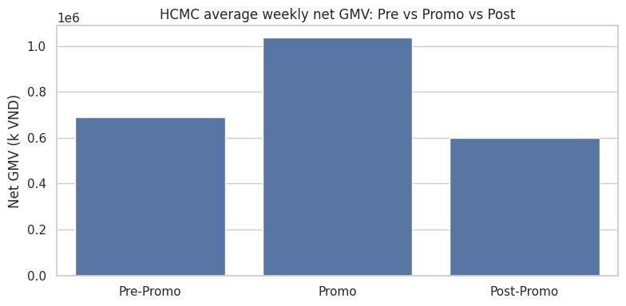

```python
plot_df = city_persistence[city_persistence["city"] == "Ho Chi Minh City"].copy()

plt.figure(figsize=(8,4))
sns.barplot(data=plot_df, x="period", y="avg_weekly_net_gmv", order=["Pre-Promo", "Promo", "Post-Promo"])
plt.title("HCMC average weekly net GMV: Pre vs Promo vs Post")
plt.xlabel("")
plt.ylabel("Net GMV (k VND)")
plt.tight_layout()
plt.show()
```

Total net GMV in HCMC rises sharply during promo but declines in post-promo, showing that topline gains were not maintained once incentives were withdrawn.

### HCMC Net GMV by Service: Pre vs Promo vs Post

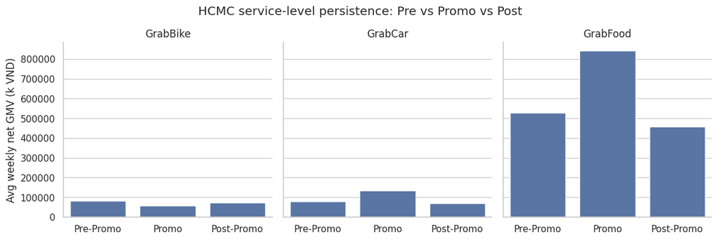

```python
plot_df = hcmc_service_persistence.copy()

g = sns.catplot(
    data=plot_df,
    kind="bar",
    x="period",
    y="avg_weekly_net_gmv",
    col="service_type",
    order=["Pre-Promo", "Promo", "Post-Promo"],
    height=4,
    aspect=1.0
)

g.set_titles("{col_name}")
g.set_axis_labels("", "Avg weekly net GMV (k VND)")
g.fig.suptitle("HCMC service-level persistence: Pre vs Promo vs Post", y=1.05)
plt.show()
```

By service, HCMC’s net GMV pattern reinforces that promo-period growth was concentrated and temporary, with post-promo levels retreating from peak performance, especially in GrabFood.

## Decision Scorecard

| Decision question | What the analysis shows | So what for Hanoi rollout? |
| --- | --- | --- |
| Did HCMC GMV increase during promo? | Yes, materially. | Establishes uplift, but not causality. |
| Was the gain broad-based across both combo services? | Only partially; strongest uplift is concentrated in GrabFood. | Weakens the replication case for a true Food-Bike combo. |
| Is Hanoi behaving like a clean comparable market? | Not fully; baseline comparability is directionally similar but not clean enough. | External validity remains limited. |
| Could weather explain part of the uplift? | Yes; rainfall likely amplified HCMC performance, especially via GrabFood. | Attribution is weaker than topline GMV suggests. |
| Did gains persist after promo? | Only weakly; post-promo performance softened materially. | Suggests limited structural durability. |

## Final Recommendation

**Recommendation: Do not approve an immediate full rollout to Hanoi.**

The HCMC uplift is real, but the current evidence is **not strong enough** to conclude that the **Super-Combo Voucher itself** caused a **scalable, repeatable gain** that will transfer to Hanoi.

**Three reasons:**

1. The uplift appears concentrated in **GrabFood** and **transaction frequency**, not a clear, broad-based combo effect across **both target services**.
2. HCMC experienced **unusually high rainfall** during the promo window, making weather a **plausible confounder**, especially for **delivery demand**.
3. **Post-promo performance** does not indicate a clearly **durable structural shift**.

=> **Recommended action instead:** run a **controlled Hanoi test** or **phased rollout** with **pre-defined success criteria** on **incremental GMV, active users, cross-service adoption, and subsidy efficiency**.